# Post-release defects with exception handling: model construction and analysis

# Setup, Constants and Functions, Load data

```r
suppressMessages(require(rms, quietly = TRUE, warn.conflicts = FALSE))
require(splines, quietly = TRUE)
require(plotly, quietly = TRUE, warn.conflicts = FALSE)
require(Hmisc, quietly = TRUE)
require(e1071, quietly = TRUE)
require(caret, quietly = TRUE)
require(BiodiversityR, quietly = TRUE)
require(logistf, quietly = TRUE)
require(rmarkdown, quietly = TRUE)
```

# Constants and Functions

```r
NA_THRESHOLD = 0.03
CORR_THRESHOLD = 0.7

# Remove variables that correlation are non-relevant. These are the identification variables or dependant variable.
# Warning: This is redefined for each model construction!!!
dropToPredict = c("File.Path", "Project", "Language", "Table.Name","Name","Kind","Table.Name", "X..Bugs.Post", "File", "Distinct.count.of.Issue.Key.POST", "X..Catch", "X..Throws")

source(file = "construction_functions.R")
source(file = "analysis_functions.R")
```

# Load combined data with no missing

```r
load(file ="0-all_no_missing.RData")
```

# Models

We build in total many models. They were per project, per group of files (i.e. all files, with catch blocks, with throws, with both) and finally we built a base model for reference, and then we include exception handling features according to the model construction analysis.

# 1- Preliminary analysis and results - All files including zero catch and zero throws

```r
all_list_omitted_1 = all_no_missing
all_list_omitted = all_list_omitted_1

all_list_omitted = vector("list", 0)
for (i in 1:length(projects)) {
  print(paste("Project:", projects[i]))
  temp_data = as.data.frame(all_list_omitted_1[i])
  print(paste("nrow:",nrow(temp_data),"ncol:",ncol(temp_data)))

  #Don't do anything in here, repack only.

  all_list_omitted <- c(all_list_omitted, list(list(project=projects[i], data=temp_data)))
}
```

```
## [1] "Project: hadoop-2.6"
## [1] "nrow: 3662 ncol: 159"
## [1] "Project: hibernate-5.0"
## [1] "nrow: 3450 ncol: 159"
## [1] "Project: umbraco-7.6"
## [1] "nrow: 3083 ncol: 159"
```

## Predictor budget estimation (MC2) and normality adjustment (MC3)

```r
modelSelectionAndNormalityAdjustment(all_list_omitted)
```

```
## [1] "Project: hadoop-2.6 D.F. Budget: 244"
## [1] "Project: hibernate-5.0 D.F. Budget: 230"
## [1] "Project: umbraco-7.6 D.F. Budget: 205"
## [1] "Project: hadoop-2.6 skewness, 11.2075144591477"
## [1] "Project: hadoop-2.6 kurtosis, 206.311714751217"
## [1] "Project: hibernate-5.0 skewness, 5.65031532192437"
## [1] "Project: hibernate-5.0 kurtosis, 47.2644938004385"
## [1] "Project: umbraco-7.6 skewness, 7.94132944771468"
## [1] "Project: umbraco-7.6 kurtosis, 75.8810831241314"
```

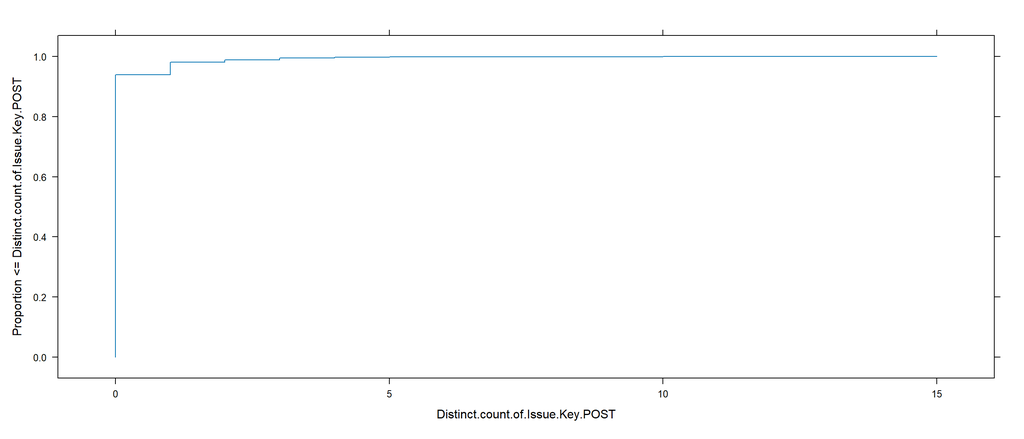

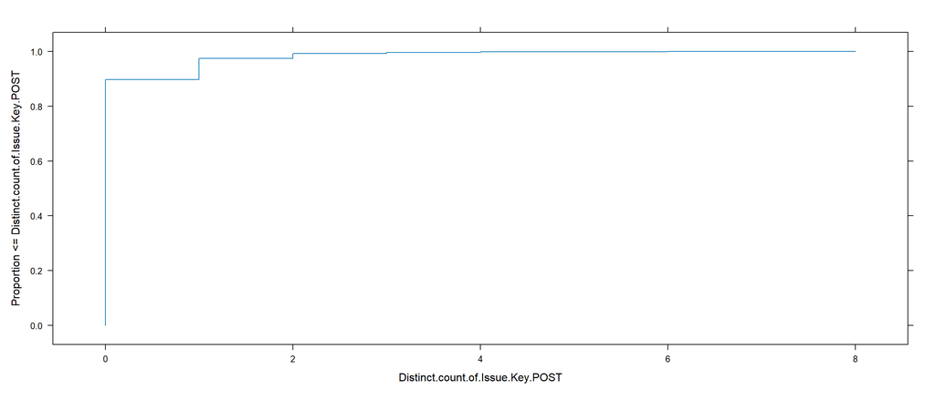

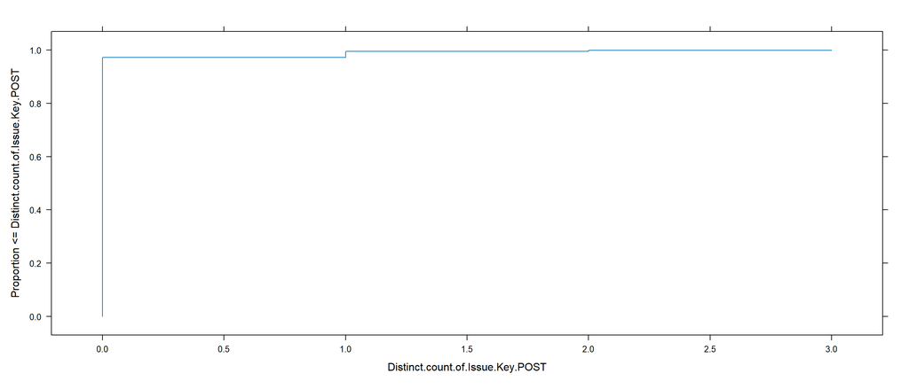

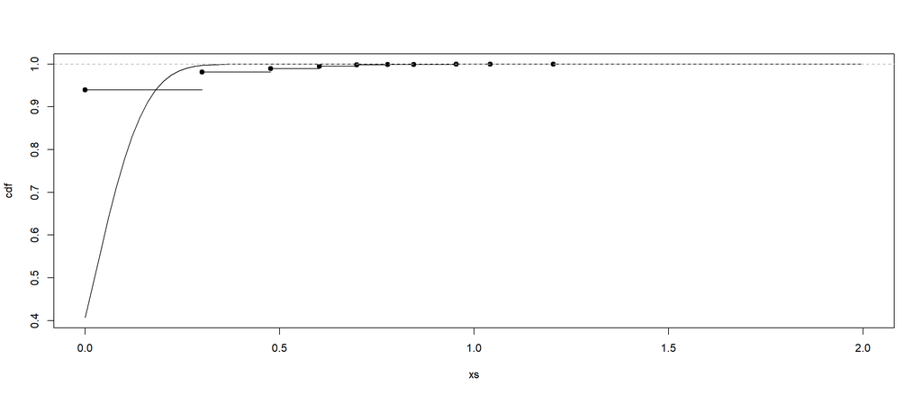

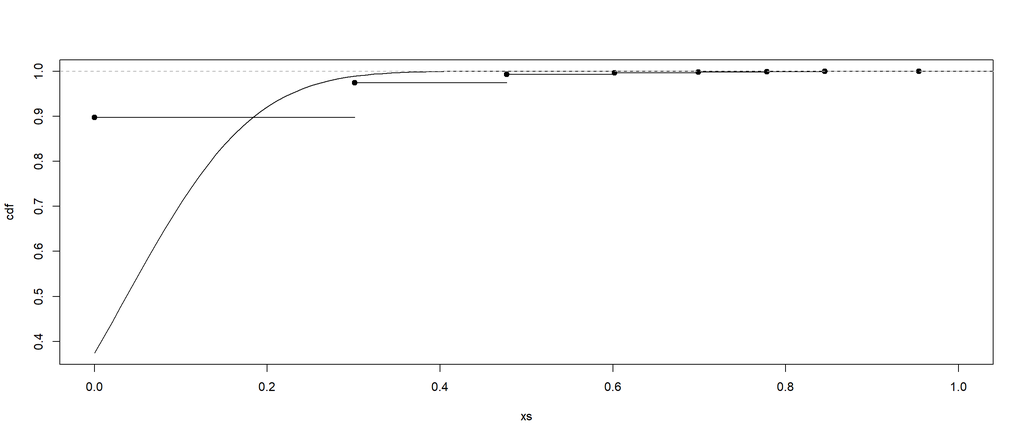

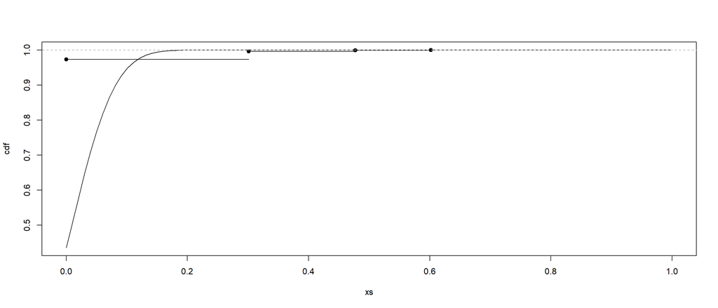

## Model 0 - BASE Only Before looking into models that include catch blocks or throws blocks data we would consider also models that only have base metrics. We aim to understand the difference between BASE only metrics and BASE + EH Metrics ### Drop variables

```r
all_list_omitted_m0 = vector("list", 0)
for (i in 1:length(projects)) {
  print(paste("Project:", projects[i]))
  temp_data = all_list_omitted[[i]]$data

  temp_data = temp_data[,!(names(temp_data) %in% catch_names)]
  temp_data = temp_data[,!(names(temp_data) %in% try_names)]
  temp_data = temp_data[,!(names(temp_data) %in% throws_names)]

  print(nrow(temp_data))
  print(names(temp_data))

  all_list_omitted_m0 <- c(all_list_omitted_m0, list(temp_data))
}
```

```
## [1] "Project: hadoop-2.6"
## [1] 3662
##  [1] "fileSize"                           "Distinct.count.of.Author.Email.PRE"
##  [3] "Distinct.count.of.Commit.Hash.PRE"  "Distinct.count.of.Issue.Key.POST"
##  [5] "Distinct.count.of.Issue.Key.PRE"    "Churn.PRE"
##  [7] "AvgCyclomaticModified"              "AvgCyclomaticStrict"
##  [9] "AvgCyclomatic"                      "AvgEssential"
## [11] "AvgLineBlank"                       "AvgLineCode"
## [13] "AvgLineComment"                     "AvgLine"
## [15] "CountDeclClassMethod"               "CountDeclClassVariable"
## [17] "CountDeclClass"                     "CountDeclFunction"
## [19] "CountDeclInstanceMethod"            "CountDeclInstanceVariable"
## [21] "CountDeclMethodDefault"             "CountDeclMethodPrivate"
## [23] "CountDeclMethodProtected"           "CountDeclMethodPublic"
## [25] "CountDeclMethod"                    "CountLineBlank"
```

[output cut: 66 more lines]

```r
dropToPredict = c("File.Path",  "Project", "Language", "Table.Name","Name","Kind", "X..Bugs.Post", "File", "Distinct.count.of.Issue.Key.POST")
```

### Correlation analysis (MC4), Redundancy Analysis (MC5), Budget based correlation analysis (MC6)

```r
all_list_model_m0 = dataApplyReduction(all_list_omitted_m0)
```

```
## [1] "Project: hadoop-2.6"
```

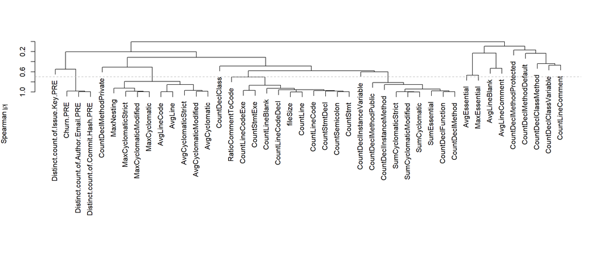

```
## [1] "NumberOfMetricsInitial: 45"
## [1] "NumberOfMetricsKept: 15"
## [1] "Distinct.count.of.Issue.Key.PRE + Churn.PRE + AvgEssential + AvgLineBlank + AvgLineComment + CountDeclClassMethod + CountDeclClassVariable + CountDeclClass + CountDeclInstanceVariable + CountDeclMethodDefault + CountDeclMethodPrivate + CountDeclMethodProtected + CountDeclMethodPublic + Count…
## [1] "Project: hibernate-5.0"
```

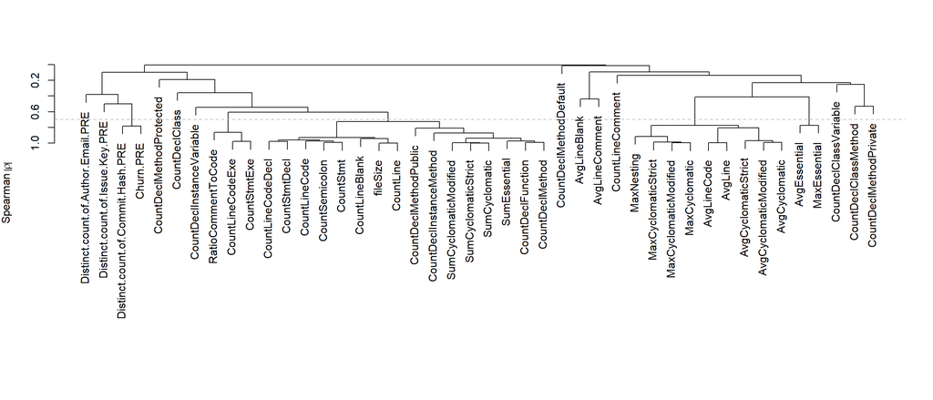

```
## [1] "NumberOfMetricsInitial: 45"
## [1] "NumberOfMetricsKept: 16"
## [1] "Distinct.count.of.Author.Email.PRE + Distinct.count.of.Issue.Key.PRE + AvgCyclomaticModified + AvgEssential + AvgLineBlank + AvgLineComment + CountDeclClassMethod + CountDeclClassVariable + CountDeclClass + CountDeclInstanceVariable + CountDeclMethodDefault + CountDeclMethodPrivate + CountDe…
## [1] "Project: umbraco-7.6"
```

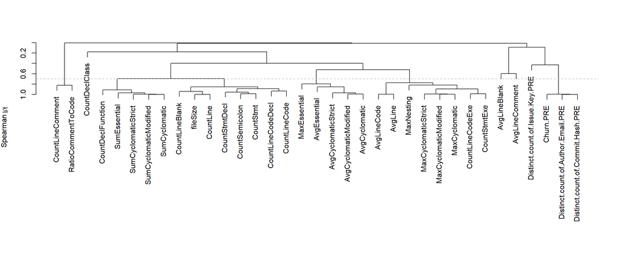

```
## [1] "NumberOfMetricsInitial: 45"
## [1] "NumberOfMetricsKept: 8"
## [1] "Distinct.count.of.Author.Email.PRE + Distinct.count.of.Issue.Key.PRE + AvgEssential + AvgLineBlank + AvgLineComment + CountDeclClass + CountDeclFunction + RatioCommentToCode"
## [1] "Project: hadoop-2.6"
## [1] "Redudant variables: CountDeclMethodPrivate,␣CountDeclClassMethod,␣CountDeclClass,␣CountDeclInstanceVariable,␣CountLineComment"
## [1] "Distinct.count.of.Issue.Key.POST + Distinct.count.of.Issue.Key.PRE + Churn.PRE + AvgEssential + AvgLineBlank + AvgLineComment + CountDeclClassVariable + CountDeclMethodDefault + CountDeclMethodProtected + CountDeclMethodPublic + File + Kind + MaxEssential + Name + Table.Name"
## [1] "Project: hibernate-5.0"
## [1] "Redudant variables: "
## [1] "Distinct.count.of.Author.Email.PRE + Distinct.count.of.Issue.Key.POST + Distinct.count.of.Issue.Key.PRE + AvgCyclomaticModified + AvgEssential + AvgLineBlank + AvgLineComment + CountDeclClassMethod + CountDeclClassVariable + CountDeclClass + CountDeclInstanceVariable + CountDeclMethodDefault…
## [1] "Project: umbraco-7.6"
## [1] "Redudant variables: "
## [1] "Distinct.count.of.Author.Email.PRE + Distinct.count.of.Issue.Key.POST + Distinct.count.of.Issue.Key.PRE + AvgEssential + AvgLineBlank + AvgLineComment + CountDeclClass + CountDeclFunction + File + Kind + Name + RatioCommentToCode + Table.Name"
## [1] "Project: hadoop-2.6"
## [1] "NumberOfMetricsInitial: 10 Budget: 244 Over Budget: FALSE NumberOfMetricsKept: 10 CorrelationCutoff: 0.7"
## [1] "Project: hibernate-5.0"
## [1] "NumberOfMetricsInitial: 16 Budget: 230 Over Budget: FALSE NumberOfMetricsKept: 16 CorrelationCutoff: 0.7"
## [1] "Project: umbraco-7.6"
## [1] "NumberOfMetricsInitial: 8 Budget: 205 Over Budget: FALSE NumberOfMetricsKept: 8 CorrelationCutoff: 0.7"
```

### Setup formulas

```r
form_list_bin_m0 = dataSetupFormulasBinary(all_list_model_m0)
```

```
## [1] "Project: hadoop-2.6"
## [1] "Distinct.count.of.Issue.Key.PRE + Churn.PRE + AvgEssential + AvgLineBlank + AvgLineComment + CountDeclClassVariable + CountDeclMethodDefault + CountDeclMethodProtected + CountDeclMethodPublic + MaxEssential"
## [1] "Project: hibernate-5.0"
## [1] "Distinct.count.of.Author.Email.PRE + Distinct.count.of.Issue.Key.PRE + AvgCyclomaticModified + AvgEssential + AvgLineBlank + AvgLineComment + CountDeclClassMethod + CountDeclClassVariable + CountDeclClass + CountDeclInstanceVariable + CountDeclMethodDefault + CountDeclMethodPrivate + CountDe…
## [1] "Project: umbraco-7.6"
## [1] "Distinct.count.of.Author.Email.PRE + Distinct.count.of.Issue.Key.PRE + AvgEssential + AvgLineBlank + AvgLineComment + CountDeclClass + CountDeclFunction + RatioCommentToCode"
```

### Fit regression model (MC7)

```r
models_1_BASE = modelFitLogistic(all_list_model_m0,form_list_bin_m0,"ALL.BASE")
```

```
## [1] "Project: hadoop-2.6"
## Logistic Regression Model
##
## lrm(formula = as.formula(form_bin), data = temp_data_log, x = T,
##     y = T)
##
##                        Model Likelihood       Discrimination    Rank Discrim.
##                              Ratio Test              Indexes          Indexes
## Obs          3662    LR chi2     437.88       R2       0.306    C       0.843
##  FALSE       3439    d.f.            10     R2(10,3662)0.110    Dxy     0.686
##  TRUE         223    Pr(> chi2) <0.0001    R2(10,628.3)0.494    gamma   0.687
## max |deriv| 2e-06                             Brier    0.045    tau-a   0.079
##
##                                 Coef    S.E.   Wald Z Pr(>|Z|)
## Intercept                       -4.3614 0.2832 -15.40 <0.0001
## Distinct.count.of.Issue.Key.PRE  1.9006 0.4227   4.50 <0.0001
## Churn.PRE                        0.7777 0.0906   8.58 <0.0001
## AvgEssential                    -0.9794 0.9775  -1.00 0.3164
## AvgLineBlank                     0.7203 0.6229   1.16 0.2476
## AvgLineComment                   0.7669 0.5625   1.36 0.1728
## CountDeclClassVariable           0.6099 0.2040   2.99 0.0028
## CountDeclMethodDefault           0.3829 0.1924   1.99 0.0466
## CountDeclMethodProtected        -0.0073 0.2461  -0.03 0.9763
## CountDeclMethodPublic           -0.0068 0.1907  -0.04 0.9717
## MaxEssential                     1.3270 0.4330   3.06 0.0022
##
## [1] "Project: hibernate-5.0"
## Logistic Regression Model
##
## lrm(formula = as.formula(form_bin), data = temp_data_log, x = T,
##     y = T)
##
##                        Model Likelihood      Discrimination    Rank Discrim.
##                              Ratio Test             Indexes          Indexes
## Obs          3450    LR chi2     381.53      R2       0.216    C       0.788
##  FALSE       3096    d.f.            16    R2(16,3450)0.101    Dxy     0.576
##  TRUE         354    Pr(> chi2) <0.0001     R2(16,953)0.319    gamma   0.576
## max |deriv| 3e-06                            Brier    0.079    tau-a   0.106
##
##                                    Coef    S.E.   Wald Z Pr(>|Z|)
```

[output cut: 26 more lines]

```
## Obs          3083    LR chi2      94.37      R2       0.136    C       0.749
##  FALSE       2999    d.f.             8     R2(8,3083)0.028    Dxy     0.498
##  TRUE          84    Pr(> chi2) <0.0001    R2(8,245.1)0.297    gamma   0.499
## max |deriv| 9e-07                            Brier    0.025    tau-a   0.026
##
##                                    Coef    S.E.   Wald Z Pr(>|Z|)
## Intercept                          -5.4088 0.5125 -10.55 <0.0001
## Distinct.count.of.Author.Email.PRE  3.1202 0.6078   5.13 <0.0001
## Distinct.count.of.Issue.Key.PRE     0.3255 1.0879   0.30 0.7648
## AvgEssential                        0.8683 1.2120   0.72 0.4737
## AvgLineBlank                        1.5648 0.6844   2.29 0.0222
## AvgLineComment                     -1.0431 0.8267  -1.26 0.2070
## CountDeclClass                     -0.4660 1.0231  -0.46 0.6488
## CountDeclFunction                   1.3171 0.2756   4.78 <0.0001
## RatioCommentToCode                  1.5581 0.9372   1.66 0.0964
```

## Model 1 - BASE + N Throws + N Catch

As we can see in the clusters, all the throws blocks data where correlated to each other. Similarly, all catch blocks data and try blocks data were correlated to each other. In this situation, we can see that exception handling metrics are important and we will dig further to understand it better. ### Drop variables

```r
all_list_omitted_m1 = vector("list", 0)
for (i in 1:length(projects)) {
  print(paste("Project:", projects[i]))
  temp_data = all_list_omitted[[i]]$data

  keepForID = c("Project", "File.Path")
  keepForCatch = c("X..Catch",keepForID)
  keepForTry = c(keepForID)
  keepForThrows = c("X..Throws", keepForID)

  catch_names_drop = catch_names[!(catch_names %in% keepForCatch)]
  try_names_drop = try_names[!(try_names %in% keepForTry)]
  throws_names_drop = throws_names[!(throws_names %in% keepForThrows)]

  temp_data = temp_data[,!(names(temp_data) %in% catch_names_drop)]
  temp_data = temp_data[,!(names(temp_data) %in% try_names_drop)]
  temp_data = temp_data[,!(names(temp_data) %in% throws_names_drop)]

  print(names(temp_data))

  all_list_omitted_m1 <- c(all_list_omitted_m1, list(temp_data))
}
```

```
## [1] "Project: hadoop-2.6"
##  [1] "File.Path"                          "Project"
##  [3] "fileSize"                           "Distinct.count.of.Author.Email.PRE"
##  [5] "Distinct.count.of.Commit.Hash.PRE"  "Distinct.count.of.Issue.Key.POST"
##  [7] "Distinct.count.of.Issue.Key.PRE"    "Churn.PRE"
##  [9] "AvgCyclomaticModified"              "AvgCyclomaticStrict"
## [11] "AvgCyclomatic"                      "AvgEssential"
## [13] "AvgLineBlank"                       "AvgLineCode"
## [15] "AvgLineComment"                     "AvgLine"
## [17] "CountDeclClassMethod"               "CountDeclClassVariable"
## [19] "CountDeclClass"                     "CountDeclFunction"
## [21] "CountDeclInstanceMethod"            "CountDeclInstanceVariable"
## [23] "CountDeclMethodDefault"             "CountDeclMethodPrivate"
## [25] "CountDeclMethodProtected"           "CountDeclMethodPublic"
## [27] "CountDeclMethod"                    "CountLineBlank"
```

[output cut: 69 more lines]

```r
dropToPredict = c("File.Path",  "Project", "Language", "Table.Name","Name","Kind", "X..Bugs.Post", "File", "Distinct.count.of.Issue.Key.POST")
```

### Correlation analysis (MC4), Redundancy Analysis (MC5), Budget based correlation analysis (MC6)

```r
all_list_model_m1 = dataApplyReduction(all_list_omitted_m1)
```

```
## [1] "Project: hadoop-2.6"
```

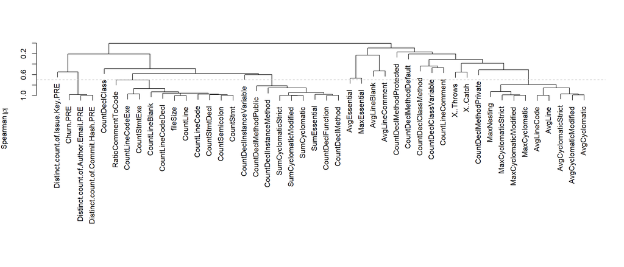

```
## [1] "NumberOfMetricsInitial: 47"
## [1] "NumberOfMetricsKept: 18"
## [1] "Distinct.count.of.Author.Email.PRE + Distinct.count.of.Issue.Key.PRE + AvgEssential + AvgLineBlank + AvgLineComment + CountDeclClassMethod + CountDeclClassVariable + CountDeclClass + CountDeclInstanceVariable + CountDeclMethodDefault + CountDeclMethodPrivate + CountDeclMethodProtected + Coun…
## [1] "Project: hibernate-5.0"
```

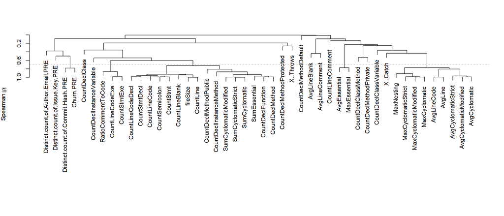

```
## [1] "NumberOfMetricsInitial: 47"
## [1] "NumberOfMetricsKept: 18"
## [1] "Distinct.count.of.Author.Email.PRE + Distinct.count.of.Issue.Key.PRE + AvgCyclomaticModified + AvgEssential + AvgLineBlank + AvgLineComment + CountDeclClassMethod + CountDeclClassVariable + CountDeclClass + CountDeclInstanceVariable + CountDeclMethodDefault + CountDeclMethodPrivate + CountDe…
## [1] "Project: umbraco-7.6"
```

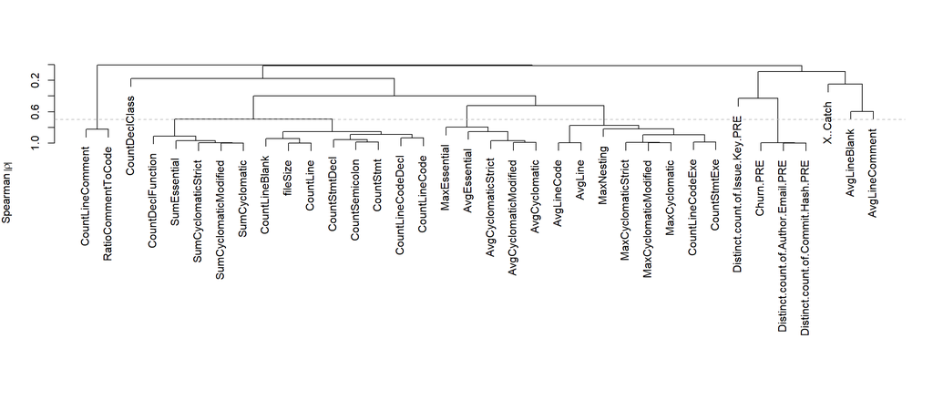

```
## [1] "NumberOfMetricsInitial: 47"
## [1] "NumberOfMetricsKept: 9"
## [1] "Distinct.count.of.Author.Email.PRE + Distinct.count.of.Issue.Key.PRE + AvgEssential + AvgLineBlank + AvgLineComment + CountDeclClass + CountDeclFunction + RatioCommentToCode + X..Catch"
## [1] "Project: hadoop-2.6"
## [1] "Redudant variables: CountDeclMethodPrivate,␣CountDeclClassMethod,␣X..Throws,␣CountDeclClass,␣CountDeclInstanceVariable,␣CountDeclMethodProtected,␣CountLineComment"
## [1] "File.Path + Project + Distinct.count.of.Author.Email.PRE + Distinct.count.of.Issue.Key.POST + Distinct.count.of.Issue.Key.PRE + AvgEssential + AvgLineBlank + AvgLineComment + CountDeclClassVariable + CountDeclMethodDefault + CountDeclMethodPublic + File + Kind + MaxEssential + Name + RatioCo…
## [1] "Project: hibernate-5.0"
## [1] "Redudant variables: "
## [1] "File.Path + Project + Distinct.count.of.Author.Email.PRE + Distinct.count.of.Issue.Key.POST + Distinct.count.of.Issue.Key.PRE + AvgCyclomaticModified + AvgEssential + AvgLineBlank + AvgLineComment + CountDeclClassMethod + CountDeclClassVariable + CountDeclClass + CountDeclInstanceVariable + …
## [1] "Project: umbraco-7.6"
## [1] "Redudant variables: "
## [1] "File.Path + Project + Distinct.count.of.Author.Email.PRE + Distinct.count.of.Issue.Key.POST + Distinct.count.of.Issue.Key.PRE + AvgEssential + AvgLineBlank + AvgLineComment + CountDeclClass + CountDeclFunction + File + Kind + Name + RatioCommentToCode + Table.Name + X..Catch"
## [1] "Project: hadoop-2.6"
## [1] "NumberOfMetricsInitial: 11 Budget: 244 Over Budget: FALSE NumberOfMetricsKept: 11 CorrelationCutoff: 0.7"
## [1] "Project: hibernate-5.0"
## [1] "NumberOfMetricsInitial: 18 Budget: 230 Over Budget: FALSE NumberOfMetricsKept: 18 CorrelationCutoff: 0.7"
## [1] "Project: umbraco-7.6"
## [1] "NumberOfMetricsInitial: 9 Budget: 205 Over Budget: FALSE NumberOfMetricsKept: 9 CorrelationCutoff: 0.7"
```

### Setup formulas

```r
form_list_bin_m1 = dataSetupFormulasBinary(all_list_model_m1)
```

```
## [1] "Project: hadoop-2.6"
## [1] "Distinct.count.of.Author.Email.PRE + Distinct.count.of.Issue.Key.PRE + AvgEssential + AvgLineBlank + AvgLineComment + CountDeclClassVariable + CountDeclMethodDefault + CountDeclMethodPublic + MaxEssential + RatioCommentToCode + X..Catch"
## [1] "Project: hibernate-5.0"
## [1] "Distinct.count.of.Author.Email.PRE + Distinct.count.of.Issue.Key.PRE + AvgCyclomaticModified + AvgEssential + AvgLineBlank + AvgLineComment + CountDeclClassMethod + CountDeclClassVariable + CountDeclClass + CountDeclInstanceVariable + CountDeclMethodDefault + CountDeclMethodPrivate + CountDe…
## [1] "Project: umbraco-7.6"
## [1] "Distinct.count.of.Author.Email.PRE + Distinct.count.of.Issue.Key.PRE + AvgEssential + AvgLineBlank + AvgLineComment + CountDeclClass + CountDeclFunction + RatioCommentToCode + X..Catch"
```

### Fit regression model (MC7)

```r
models_1_BSEH = modelFitLogistic(all_list_model_m1,form_list_bin_m1,"ALL.BSEH")
```

```
## [1] "Project: hadoop-2.6"
## Logistic Regression Model
##
## lrm(formula = as.formula(form_bin), data = temp_data_log, x = T,
##     y = T)
##
##                         Model Likelihood       Discrimination    Rank Discrim.
##                               Ratio Test              Indexes          Indexes
## Obs           3662    LR chi2     482.25       R2       0.335    C       0.855
##  FALSE        3439    d.f.            11     R2(11,3662)0.121    Dxy     0.710
##  TRUE          223    Pr(> chi2) <0.0001    R2(11,628.3)0.528    gamma   0.710
## max |deriv| 0.0002                             Brier    0.043    tau-a   0.081
##
##                                    Coef    S.E.   Wald Z Pr(>|Z|)
## Intercept                          -3.4030 0.4134 -8.23  <0.0001
## Distinct.count.of.Author.Email.PRE  3.8178 0.4021  9.50  <0.0001
## Distinct.count.of.Issue.Key.PRE     0.4338 0.4910  0.88  0.3769
## AvgEssential                       -1.4945 1.0469 -1.43  0.1534
## AvgLineBlank                        0.4635 0.6410  0.72  0.4696
## AvgLineComment                      0.3672 0.5883  0.62  0.5326
## CountDeclClassVariable              0.3420 0.2122  1.61  0.1070
## CountDeclMethodDefault              0.1828 0.1948  0.94  0.3480
## CountDeclMethodPublic              -0.3671 0.1982 -1.85  0.0640
## MaxEssential                        1.1103 0.4488  2.47  0.0134
## RatioCommentToCode                 -1.9394 0.6839 -2.84  0.0046
## X..Catch                            0.6860 0.2468  2.78  0.0054
##
## [1] "Project: hibernate-5.0"
## Logistic Regression Model
##
## lrm(formula = as.formula(form_bin), data = temp_data_log, x = T,
##     y = T)
##
##                        Model Likelihood      Discrimination    Rank Discrim.
##                              Ratio Test             Indexes          Indexes
## Obs          3450    LR chi2     394.22      R2       0.223    C       0.791
##  FALSE       3096    d.f.            18    R2(18,3450)0.103    Dxy     0.582
##  TRUE         354    Pr(> chi2) <0.0001     R2(18,953)0.326    gamma   0.583
## max |deriv| 3e-06                            Brier    0.079    tau-a   0.107
##
```

[output cut: 30 more lines]

```
##  FALSE       2999    d.f.             9     R2(9,3083)0.030    Dxy     0.510
##  TRUE          84    Pr(> chi2) <0.0001    R2(9,245.1)0.318    gamma   0.512
## max |deriv| 5e-07                            Brier    0.024    tau-a   0.027
##
##                                    Coef    S.E.   Wald Z Pr(>|Z|)
## Intercept                          -5.3076 0.5079 -10.45 <0.0001
## Distinct.count.of.Author.Email.PRE  3.0602 0.6169   4.96 <0.0001
## Distinct.count.of.Issue.Key.PRE     0.2517 1.1103   0.23 0.8206
## AvgEssential                        1.2942 1.1674   1.11 0.2676
## AvgLineBlank                        1.3611 0.6901   1.97 0.0486
## AvgLineComment                     -1.4642 0.8769  -1.67 0.0950
## CountDeclClass                     -0.4619 1.0443  -0.44 0.6582
## CountDeclFunction                   0.9862 0.2991   3.30 0.0010
## RatioCommentToCode                  1.5917 0.9281   1.71 0.0864
## X..Catch                            1.5400 0.5152   2.99 0.0028
```

## Model Analysis for ALL

In this section, we present the selected statistics for our analysis. As explained in our approach, they are the steps: MC7, MA1, MA2, MA3 and MA4.

Here we extract the selected statistics and we add the data (columns) to an object that will be exported to CSV in the section Output.

### Fit regression model (MC7): summary stats

```r
model_things_1_BASE = vector("list", 0)
model_things_1_BSEH = vector("list", 0)
model_things_1_BASE = modelStats(models_1_BASE)
model_things_1_BSEH = modelStats(models_1_BSEH)
```

### Model stability assessment (MA1)

```r
model_things_1_BASE = modelValidate(models_1_BASE, model_things_1_BASE)
model_things_1_BSEH = modelValidate(models_1_BSEH, model_things_1_BSEH)
```

### Model significant variables

```r
model_things_1_BASE = modelSignificance(models_1_BASE, model_things_1_BASE)
```

```
## [1] "project:  hadoop-2.6 model:  ALL.BASE"
##                 Wald Statistics          Response: Distinct.count.of.Issue.Key.POST > 0
##
##  Factor                          Chi-Square d.f. P
##  Distinct.count.of.Issue.Key.PRE  20.22      1   <.0001
##  Churn.PRE                        73.62      1   <.0001
##  AvgEssential                      1.00      1   0.3164
##  AvgLineBlank                      1.34      1   0.2476
##  AvgLineComment                    1.86      1   0.1728
##  CountDeclClassVariable            8.94      1   0.0028
##  CountDeclMethodDefault            3.96      1   0.0466
##  CountDeclMethodProtected          0.00      1   0.9763
##  CountDeclMethodPublic             0.00      1   0.9717
##  MaxEssential                      9.39      1   0.0022
##  TOTAL                           365.46     10   <.0001
## [1] "project:  hibernate-5.0 model:  ALL.BASE"
##                 Wald Statistics          Response: Distinct.count.of.Issue.Key.POST > 0
##
##  Factor                             Chi-Square d.f. P
##  Distinct.count.of.Author.Email.PRE   2.65      1   0.1035
##  Distinct.count.of.Issue.Key.PRE     23.29      1   <.0001
##  AvgCyclomaticModified                2.46      1   0.1168
##  AvgEssential                         0.01      1   0.9331
##  AvgLineBlank                         4.65      1   0.0310
##  AvgLineComment                       0.05      1   0.8187
##  CountDeclClassMethod                 3.76      1   0.0526
##  CountDeclClassVariable               3.41      1   0.0649
##  CountDeclClass                       1.50      1   0.2201
##  CountDeclInstanceVariable            7.72      1   0.0054
##  CountDeclMethodDefault               0.04      1   0.8402
##  CountDeclMethodPrivate              10.05      1   0.0015
##  CountDeclMethodProtected             0.46      1   0.4973
##  CountDeclMethodPublic               30.55      1   <.0001
##  CountLineComment                    10.48      1   0.0012
##  RatioCommentToCode                  23.78      1   <.0001
##  TOTAL                              306.17     16   <.0001
## [1] "project:  umbraco-7.6 model:  ALL.BASE"
##                 Wald Statistics          Response: Distinct.count.of.Issue.Key.POST > 0
##
##  Factor                             Chi-Square d.f. P
##  Distinct.count.of.Author.Email.PRE 26.35      1    <.0001
##  Distinct.count.of.Issue.Key.PRE     0.09      1    0.7648
##  AvgEssential                        0.51      1    0.4737
##  AvgLineBlank                        5.23      1    0.0222
##  AvgLineComment                      1.59      1    0.2070
##  CountDeclClass                      0.21      1    0.6488
##  CountDeclFunction                  22.85      1    <.0001
##  RatioCommentToCode                  2.76      1    0.0964
##  TOTAL                              99.58      8    <.0001
```

```r
model_things_1_BSEH = modelSignificance(models_1_BSEH, model_things_1_BSEH)
```

```
## [1] "project:  hadoop-2.6 model:  ALL.BSEH"
##                 Wald Statistics          Response: Distinct.count.of.Issue.Key.POST > 0
##
##  Factor                             Chi-Square d.f. P
##  Distinct.count.of.Author.Email.PRE  90.17      1   <.0001
##  Distinct.count.of.Issue.Key.PRE      0.78      1   0.3769
##  AvgEssential                         2.04      1   0.1534
##  AvgLineBlank                         0.52      1   0.4696
##  AvgLineComment                       0.39      1   0.5326
##  CountDeclClassVariable               2.60      1   0.1070
##  CountDeclMethodDefault               0.88      1   0.3480
##  CountDeclMethodPublic                3.43      1   0.0640
##  MaxEssential                         6.12      1   0.0134
##  RatioCommentToCode                   8.04      1   0.0046
##  X..Catch                             7.72      1   0.0054
##  TOTAL                              377.62     11   <.0001
## [1] "project:  hibernate-5.0 model:  ALL.BSEH"
##                 Wald Statistics          Response: Distinct.count.of.Issue.Key.POST > 0
##
##  Factor                             Chi-Square d.f. P
##  Distinct.count.of.Author.Email.PRE   1.33      1   0.2482
##  Distinct.count.of.Issue.Key.PRE     24.77      1   <.0001
##  AvgCyclomaticModified                2.30      1   0.1296
##  AvgEssential                         0.07      1   0.7946
##  AvgLineBlank                         4.17      1   0.0413
##  AvgLineComment                       0.06      1   0.7999
##  CountDeclClassMethod                 2.03      1   0.1537
##  CountDeclClassVariable               3.37      1   0.0665
##  CountDeclClass                       1.31      1   0.2527
##  CountDeclInstanceVariable            6.10      1   0.0135
##  CountDeclMethodDefault               0.02      1   0.8821
##  CountDeclMethodPrivate               8.83      1   0.0030
##  CountDeclMethodProtected             1.60      1   0.2060
##  CountDeclMethodPublic               23.12      1   <.0001
##  CountLineComment                     7.64      1   0.0057
##  RatioCommentToCode                  21.68      1   <.0001
##  X..Throws                           12.81      1   0.0003
##  X..Catch                             0.21      1   0.6476
##  TOTAL                              312.19     18   <.0001
## [1] "project:  umbraco-7.6 model:  ALL.BSEH"
##                 Wald Statistics          Response: Distinct.count.of.Issue.Key.POST > 0
##
##  Factor                             Chi-Square d.f. P
##  Distinct.count.of.Author.Email.PRE  24.61     1    <.0001
##  Distinct.count.of.Issue.Key.PRE      0.05     1    0.8206
##  AvgEssential                         1.23     1    0.2676
##  AvgLineBlank                         3.89     1    0.0486
##  AvgLineComment                       2.79     1    0.0950
##  CountDeclClass                       0.20     1    0.6582
##  CountDeclFunction                   10.87     1    0.0010
##  RatioCommentToCode                   2.94     1    0.0864
##  X..Catch                             8.93     1    0.0028
##  TOTAL                              111.72     9    <.0001
```

### Model simplification (MA2), Predictors’ explanatory power estimation (MA3), Predictors’ effect in the outcome measurement (MA4)

```r
model_things_1_BASE = modelSimplification(models_1_BASE, model_things_1_BASE)
```

```
## [1] "project:  hadoop-2.6 model:  ALL.BASE Refit"
## Logistic Regression Model
##
## lrm(formula = as.formula(final_form), data = temp_data, x = T,
##     y = T)
##
##                        Model Likelihood      Discrimination    Rank Discrim.
##                              Ratio Test             Indexes          Indexes
## Obs          3662    LR chi2     435.76      R2       0.305    C       0.842
##  FALSE       3439    d.f.             6     R2(6,3662)0.111    Dxy     0.684
##  TRUE         223    Pr(> chi2) <0.0001    R2(6,628.3)0.495    gamma   0.698
## max |deriv| 1e-06                            Brier    0.045    tau-a   0.078
##
##                                 Coef    S.E.   Wald Z Pr(>|Z|)
## Intercept                       -4.5565 0.1819 -25.04 <0.0001
## Distinct.count.of.Issue.Key.PRE  1.9348 0.4198   4.61 <0.0001
## Churn.PRE                        0.7776 0.0900   8.64 <0.0001
## AvgLineComment                   1.0720 0.4323   2.48 0.0131
## CountDeclClassVariable           0.6407 0.1821   3.52 0.0004
## CountDeclMethodDefault           0.3969 0.1810   2.19 0.0283
## MaxEssential                     1.0918 0.3207   3.40 0.0007
##
## [1] "project:  hadoop-2.6 model:  ALL.BASE Refit - summary"
## [1] "project:  hadoop-2.6 model:  ALL.BASE Refit - validate"
## [1] "project:  hadoop-2.6 model:  ALL.BASE Refit - anova"
##                 Wald Statistics          Response: Distinct.count.of.Issue.Key.POST > 0
##
##  Factor                          Chi-Square d.f. P
##  Distinct.count.of.Issue.Key.PRE  21.24     1    <.0001
##  Churn.PRE                        74.61     1    <.0001
##  AvgLineComment                    6.15     1    0.0131
##  CountDeclClassVariable           12.39     1    0.0004
##  CountDeclMethodDefault            4.81     1    0.0283
##  MaxEssential                     11.59     1    0.0007
##  TOTAL                           364.01     6    <.0001
## [1] "Distinct.count.of.Issue.Key.PRE"
## [1] "Churn.PRE"
## [1] "AvgLineComment"
## [1] "CountDeclClassVariable"
## [1] "CountDeclMethodDefault"
```

[output cut: 95 more lines]

```
##
##  Factor                             Chi-Square d.f. P
##  Distinct.count.of.Author.Email.PRE 41.64      1    <.0001
##  AvgLineBlank                        4.84      1    0.0278
##  CountDeclFunction                  27.29      1    <.0001
##  TOTAL                              97.44      3    <.0001
## [1] "Distinct.count.of.Author.Email.PRE"
## [1] "AvgLineBlank"
## [1] "CountDeclFunction"
##   Distinct.count.of.Author.Email.PRE AvgLineBlank CountDeclFunction
## 1                           0.203049    0.4469672          7.637366
## [1] "Fixed at Mean: 0.0301397678843302"
## [1] "Distinct.count.of.Author.Email.PRE  Coef at Mean + 10%: 0.0308278625922351"
## [1] "AvgLineBlank  Coef at Mean + 10%: 0.0305545699456629"
## [1] "CountDeclFunction  Coef at Mean + 10%: 0.0315383464760022"
```

```r
model_things_1_BSEH = modelSimplification(models_1_BSEH, model_things_1_BSEH)
```

```
## [1] "project:  hadoop-2.6 model:  ALL.BSEH Refit"
## Logistic Regression Model
##
## lrm(formula = as.formula(final_form), data = temp_data, x = T,
##     y = T)
##
##                         Model Likelihood      Discrimination    Rank Discrim.
##                               Ratio Test             Indexes          Indexes
## Obs           3662    LR chi2     476.36      R2       0.331    C       0.855
##  FALSE        3439    d.f.             6     R2(6,3662)0.121    Dxy     0.710
##  TRUE          223    Pr(> chi2) <0.0001    R2(6,628.3)0.527    gamma   0.710
## max |deriv| 0.0002                            Brier    0.043    tau-a   0.081
##
##                                    Coef    S.E.   Wald Z Pr(>|Z|)
## Intercept                          -3.8208 0.3011 -12.69 <0.0001
## Distinct.count.of.Author.Email.PRE  4.1195 0.3136  13.13 <0.0001
## CountDeclClassVariable              0.4366 0.2048   2.13 0.0331
## CountDeclMethodPublic              -0.3627 0.1804  -2.01 0.0444
## MaxEssential                        0.9128 0.3435   2.66 0.0079
## RatioCommentToCode                 -1.7704 0.6652  -2.66 0.0078
## X..Catch                            0.8016 0.2342   3.42 0.0006
##
## [1] "project:  hadoop-2.6 model:  ALL.BSEH Refit - summary"
## [1] "project:  hadoop-2.6 model:  ALL.BSEH Refit - validate"
## [1] "project:  hadoop-2.6 model:  ALL.BSEH Refit - anova"
##                 Wald Statistics          Response: Distinct.count.of.Issue.Key.POST > 0
##
##  Factor                             Chi-Square d.f. P
##  Distinct.count.of.Author.Email.PRE 172.53     1    <.0001
##  CountDeclClassVariable               4.54     1    0.0331
##  CountDeclMethodPublic                4.04     1    0.0444
##  MaxEssential                         7.06     1    0.0079
##  RatioCommentToCode                   7.08     1    0.0078
##  X..Catch                            11.71     1    0.0006
##  TOTAL                              375.72     6    <.0001
## [1] "Distinct.count.of.Author.Email.PRE"
## [1] "CountDeclClassVariable"
## [1] "CountDeclMethodPublic"
## [1] "MaxEssential"
## [1] "RatioCommentToCode"
```

[output cut: 95 more lines]

```
##
##  Factor                             Chi-Square d.f. P
##  Distinct.count.of.Author.Email.PRE  40.93     1    <.0001
##  CountDeclFunction                   13.39     1    0.0003
##  X..Catch                             9.79     1    0.0018
##  TOTAL                              108.60     3    <.0001
## [1] "Distinct.count.of.Author.Email.PRE"
## [1] "CountDeclFunction"
## [1] "X..Catch"
##   Distinct.count.of.Author.Email.PRE CountDeclFunction X..Catch
## 1                           0.203049          7.637366 0.170613
## [1] "Fixed at Mean: 0.0279969681007201"
## [1] "Distinct.count.of.Author.Email.PRE  Coef at Mean + 10%: 0.0286378345266873"
## [1] "CountDeclFunction  Coef at Mean + 10%: 0.0289438662470883"
## [1] "X..Catch  Coef at Mean + 10%: 0.0282613067591007"
```

## Output 1

Here we output the selected statistics from the R functions results and we output in the CSV files in the folder “output”.

```r
write.table(data.frame(model_things_1_BASE[[1]])[0,], 'output/base_test_1.csv'  , append= F, sep=',', row.names = F, col.names = T )

lapply(model_things_1_BASE, function(x) write.table( data.frame(x), 'output/base_test_1.csv'  , append= T, sep=',', row.names = F, col.names = F ))
```

```r
lapply(model_things_1_BSEH, function(x) write.table( data.frame(x), 'output/base_test_1.csv'  , append= T, sep=',', row.names = F, col.names = F ))
```

# 2- Presented results: Only Files with catch blocks

## Filtered files: dive in on Catch Blocks

We now consider that files without catch blocks is missing data. We then re-run the analysis.

```r
all_list_omitted_2 = all_no_missing
all_list_omitted = vector("list", 0)
for (i in 1:length(projects)) {
  print(paste("Project:", projects[i]))
  temp_data = as.data.frame(all_list_omitted_2[i])
  temp_data_bkp = temp_data
  print(paste("nrow:",nrow(temp_data),"ncol:",ncol(temp_data)))

  # Make 0 catch blocks become NA and remove NA's.
  No_Catch <- temp_data$X..Catch == 0
  temp_data$X..Catch[No_Catch] <- NA
  temp_data <- na.omit(temp_data)
  print(paste("nrow:",nrow(temp_data),"ncol:",ncol(temp_data)))

  if (nrow(temp_data) == 0){
    write.csv(temp_data_bkp, file = "temp_data.csv")
  }

  # Remove throws columns
  temp_data = temp_data[,!(names(temp_data) %in% throws_names)]
  print(paste("nrow:",nrow(temp_data),"ncol:",ncol(temp_data)))

  all_list_omitted <- c(all_list_omitted, list(list(project=projects[i], data=temp_data)))
}
```

```
## [1] "Project: hadoop-2.6"
## [1] "nrow: 3662 ncol: 159"
## [1] "nrow: 890 ncol: 159"
## [1] "nrow: 890 ncol: 152"
## [1] "Project: hibernate-5.0"
## [1] "nrow: 3450 ncol: 159"
## [1] "nrow: 440 ncol: 159"
## [1] "nrow: 440 ncol: 152"
## [1] "Project: umbraco-7.6"
## [1] "nrow: 3083 ncol: 159"
## [1] "nrow: 230 ncol: 159"
## [1] "nrow: 230 ncol: 152"
```

## Predictor budget estimation (MC2) and normality adjustment (MC3)

```r
modelSelectionAndNormalityAdjustment(all_list_omitted)
```

```
## [1] "Project: hadoop-2.6 D.F. Budget: 59"
## [1] "Project: hibernate-5.0 D.F. Budget: 29"
## [1] "Project: umbraco-7.6 D.F. Budget: 15"
## [1] "Project: hadoop-2.6 skewness, 6.74527749465777"
## [1] "Project: hadoop-2.6 kurtosis, 71.519920764886"
## [1] "Project: hibernate-5.0 skewness, 3.71910197274668"
## [1] "Project: hibernate-5.0 kurtosis, 17.4752211740334"
## [1] "Project: umbraco-7.6 skewness, 4.0532455757886"
## [1] "Project: umbraco-7.6 kurtosis, 20.7020533105116"
```

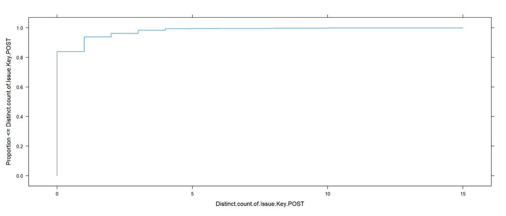

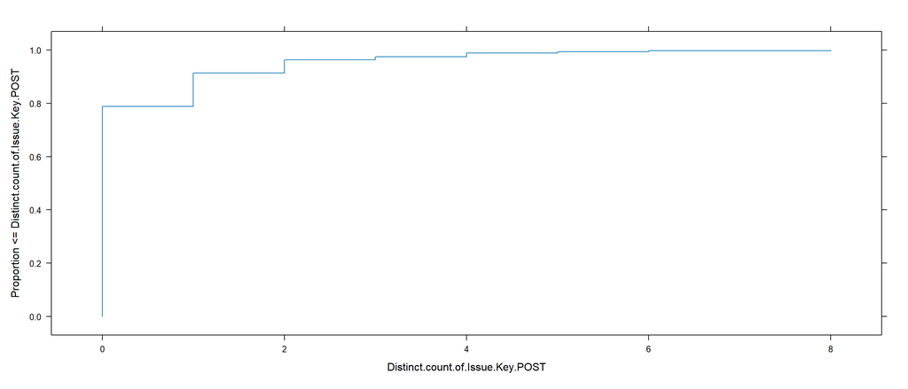

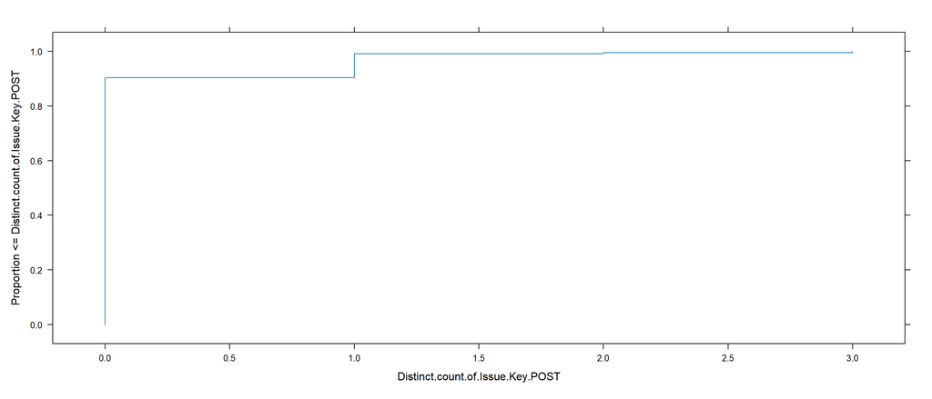

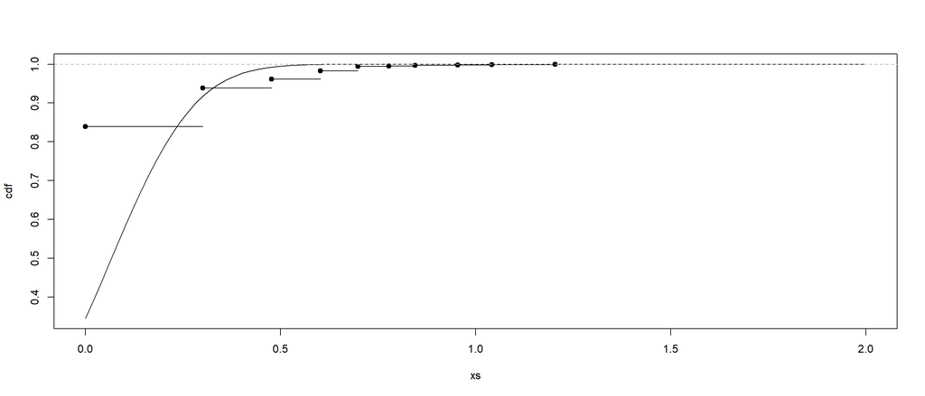

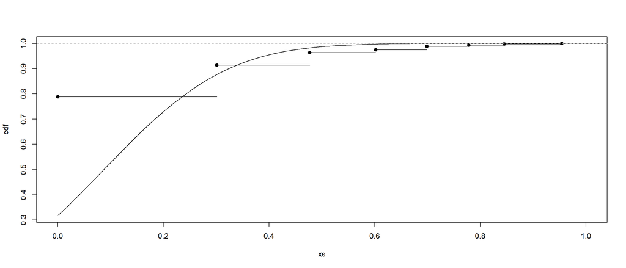

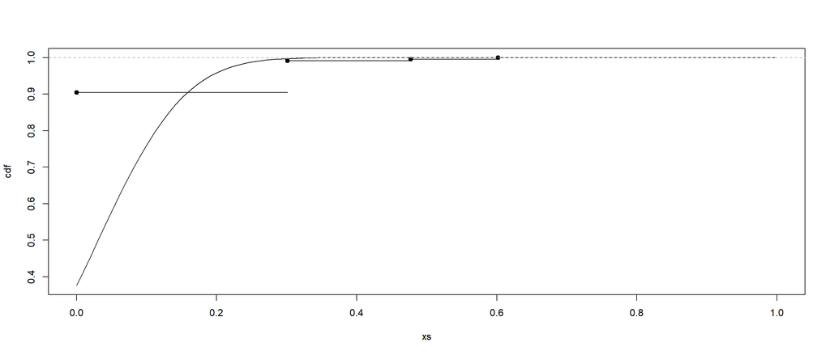

## Model 0 - BASE Only ### Drop variables

```r
all_list_omitted_m0 = vector("list", 0)
for (i in 1:length(projects)) {
  print(paste("Project:", projects[i]))
  temp_data = as.data.frame(all_list_omitted[[i]]$data)

  keepForID = c("Project", "File.Path")
  keepForCatch = c(keepForID)
  keepForTry = c(keepForID)
  keepForThrows = c(keepForID)

  catch_names_drop = catch_names[!(catch_names %in% keepForCatch)]
  try_names_drop = try_names[!(try_names %in% keepForTry)]
  throws_names_drop = throws_names[!(throws_names %in% keepForThrows)]

  temp_data = temp_data[,!(names(temp_data) %in% catch_names_drop)]
  temp_data = temp_data[,!(names(temp_data) %in% try_names_drop)]
  temp_data = temp_data[,!(names(temp_data) %in% throws_names_drop)]

  print(names(temp_data))

  all_list_omitted_m0 <- c(all_list_omitted_m0, list(temp_data))
}
```

```
## [1] "Project: hadoop-2.6"
##  [1] "fileSize"                           "Distinct.count.of.Author.Email.PRE"
##  [3] "Distinct.count.of.Commit.Hash.PRE"  "Distinct.count.of.Issue.Key.POST"
##  [5] "Distinct.count.of.Issue.Key.PRE"    "Churn.PRE"
##  [7] "AvgCyclomaticModified"              "AvgCyclomaticStrict"
##  [9] "AvgCyclomatic"                      "AvgEssential"
## [11] "AvgLineBlank"                       "AvgLineCode"
## [13] "AvgLineComment"                     "AvgLine"
## [15] "CountDeclClassMethod"               "CountDeclClassVariable"
## [17] "CountDeclClass"                     "CountDeclFunction"
## [19] "CountDeclInstanceMethod"            "CountDeclInstanceVariable"
## [21] "CountDeclMethodDefault"             "CountDeclMethodPrivate"
## [23] "CountDeclMethodProtected"           "CountDeclMethodPublic"
## [25] "CountDeclMethod"                    "CountLineBlank"
## [27] "CountLineCodeDecl"                  "CountLineCodeExe"
```

[output cut: 63 more lines]

### Correlation analysis (MC4), Redundancy Analysis (MC5), Budget based correlation analysis (MC6)

```r
all_list_model_m0 = dataApplyReduction(all_list_omitted_m0)
```

```
## [1] "Project: hadoop-2.6"
```

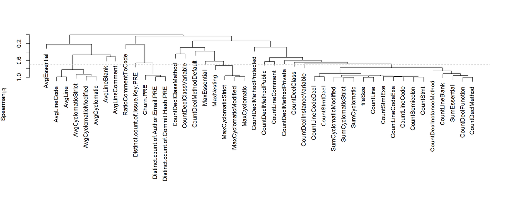

```
## [1] "NumberOfMetricsInitial: 45"
## [1] "NumberOfMetricsKept: 17"
## [1] "Distinct.count.of.Commit.Hash.PRE + AvgCyclomaticStrict + AvgEssential + AvgLineBlank + AvgLineComment + CountDeclClassMethod + CountDeclClassVariable + CountDeclClass + CountDeclInstanceVariable + CountDeclMethodDefault + CountDeclMethodPrivate + CountDeclMethodProtected + CountDeclMethodPu…
## [1] "Project: hibernate-5.0"
```

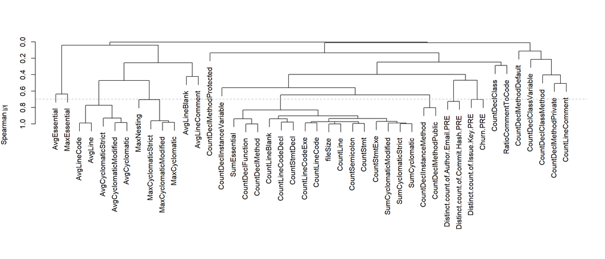

```
## [1] "NumberOfMetricsInitial: 45"
## [1] "NumberOfMetricsKept: 18"
## [1] "Distinct.count.of.Author.Email.PRE + Distinct.count.of.Issue.Key.PRE + AvgCyclomaticModified + AvgEssential + AvgLineBlank + AvgLineComment + CountDeclClassMethod + CountDeclClassVariable + CountDeclClass + CountDeclInstanceVariable + CountDeclMethodDefault + CountDeclMethodPrivate + CountDe…
## [1] "Project: umbraco-7.6"
```

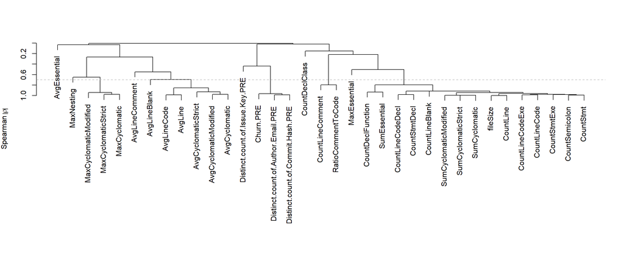

```
## [1] "NumberOfMetricsInitial: 45"
## [1] "NumberOfMetricsKept: 12"
## [1] "Distinct.count.of.Author.Email.PRE + Distinct.count.of.Issue.Key.PRE + AvgCyclomaticStrict + AvgEssential + AvgLineBlank + AvgLineComment + CountDeclClass + CountLineBlank + MaxCyclomaticModified + MaxEssential + MaxNesting + RatioCommentToCode"
## [1] "Project: hadoop-2.6"
## [1] "Redudant variables: CountDeclMethodPublic,␣CountDeclClassMethod,␣CountDeclMethodPrivate,␣CountDeclInstanceVariable,␣CountDeclClass,␣CountDeclClassVariable,␣CountLineComment"
## [1] "Distinct.count.of.Commit.Hash.PRE + Distinct.count.of.Issue.Key.POST + AvgCyclomaticStrict + AvgEssential + AvgLineBlank + AvgLineComment + CountDeclMethodDefault + CountDeclMethodProtected + File + Kind + MaxEssential + MaxNesting + Name + RatioCommentToCode + Table.Name"
## [1] "Project: hibernate-5.0"
## [1] "Redudant variables: "
## [1] "Distinct.count.of.Author.Email.PRE + Distinct.count.of.Issue.Key.POST + Distinct.count.of.Issue.Key.PRE + AvgCyclomaticModified + AvgEssential + AvgLineBlank + AvgLineComment + CountDeclClassMethod + CountDeclClassVariable + CountDeclClass + CountDeclInstanceVariable + CountDeclMethodDefault…
## [1] "Project: umbraco-7.6"
## [1] "Redudant variables: "
## [1] "Distinct.count.of.Author.Email.PRE + Distinct.count.of.Issue.Key.POST + Distinct.count.of.Issue.Key.PRE + AvgCyclomaticStrict + AvgEssential + AvgLineBlank + AvgLineComment + CountDeclClass + CountLineBlank + File + Kind + MaxCyclomaticModified + MaxEssential + MaxNesting + Name + RatioComme…
## [1] "Project: hadoop-2.6"
## [1] "NumberOfMetricsInitial: 10 Budget: 59 Over Budget: FALSE NumberOfMetricsKept: 10 CorrelationCutoff: 0.7"
## [1] "Project: hibernate-5.0"
## [1] "NumberOfMetricsInitial: 18 Budget: 29 Over Budget: FALSE NumberOfMetricsKept: 18 CorrelationCutoff: 0.7"
## [1] "Project: umbraco-7.6"
## [1] "NumberOfMetricsInitial: 12 Budget: 15 Over Budget: FALSE NumberOfMetricsKept: 12 CorrelationCutoff: 0.7"
```

### Setup formulas

```r
form_list_bin_m0 = dataSetupFormulasBinary(all_list_model_m0)
```

```
## [1] "Project: hadoop-2.6"
## [1] "Distinct.count.of.Commit.Hash.PRE + AvgCyclomaticStrict + AvgEssential + AvgLineBlank + AvgLineComment + CountDeclMethodDefault + CountDeclMethodProtected + MaxEssential + MaxNesting + RatioCommentToCode"
## [1] "Project: hibernate-5.0"
## [1] "Distinct.count.of.Author.Email.PRE + Distinct.count.of.Issue.Key.PRE + AvgCyclomaticModified + AvgEssential + AvgLineBlank + AvgLineComment + CountDeclClassMethod + CountDeclClassVariable + CountDeclClass + CountDeclInstanceVariable + CountDeclMethodDefault + CountDeclMethodPrivate + CountDe…
## [1] "Project: umbraco-7.6"
## [1] "Distinct.count.of.Author.Email.PRE + Distinct.count.of.Issue.Key.PRE + AvgCyclomaticStrict + AvgEssential + AvgLineBlank + AvgLineComment + CountDeclClass + CountLineBlank + MaxCyclomaticModified + MaxEssential + MaxNesting + RatioCommentToCode"
```

### Fit regression model (MC7)

```r
models_2_BASE = modelFitLogistic(all_list_model_m0,form_list_bin_m0,"CAT.BASE")
```

```
## [1] "Project: hadoop-2.6"
## Logistic Regression Model
##
## lrm(formula = as.formula(form_bin), data = temp_data_log, x = T,
##     y = T)
##
##                        Model Likelihood       Discrimination    Rank Discrim.
##                              Ratio Test              Indexes          Indexes
## Obs           890    LR chi2     201.97       R2       0.347    C       0.838
##  FALSE        747    d.f.            10      R2(10,890)0.194    Dxy     0.677
##  TRUE         143    Pr(> chi2) <0.0001    R2(10,360.1)0.413    gamma   0.677
## max |deriv| 6e-09                             Brier    0.100    tau-a   0.183
##
##                                   Coef    S.E.   Wald Z Pr(>|Z|)
## Intercept                         -3.8209 0.7348 -5.20  <0.0001
## Distinct.count.of.Commit.Hash.PRE  3.0387 0.3237  9.39  <0.0001
## AvgCyclomaticStrict                4.0722 1.2426  3.28  0.0010
## AvgEssential                      -4.2398 1.6071 -2.64  0.0083
## AvgLineBlank                      -1.1918 0.7955 -1.50  0.1341
## AvgLineComment                     0.2730 0.7050  0.39  0.6986
## CountDeclMethodDefault             0.2415 0.2406  1.00  0.3157
## CountDeclMethodProtected           0.0093 0.2697  0.03  0.9724
## MaxEssential                       0.8405 0.5782  1.45  0.1460
## MaxNesting                        -0.1061 1.0227 -0.10  0.9173
## RatioCommentToCode                -2.2086 1.7023 -1.30  0.1945
##
## [1] "Project: hibernate-5.0"
## Logistic Regression Model
##
## lrm(formula = as.formula(form_bin), data = temp_data_log, x = T,
##     y = T)
##
##                        Model Likelihood     Discrimination    Rank Discrim.
##                              Ratio Test            Indexes          Indexes
## Obs           440    LR chi2      81.26     R2       0.262    C       0.780
##  FALSE        347    d.f.            18    R2(18,440)0.134    Dxy     0.561
##  TRUE          93    Pr(> chi2) <0.0001    R2(18,220)0.250    gamma   0.561
## max |deriv| 2e-05                           Brier    0.133    tau-a   0.187
##
##                                    Coef    S.E.   Wald Z Pr(>|Z|)
```

[output cut: 32 more lines]

```
##
##                                    Coef    S.E.   Wald Z Pr(>|Z|)
## Intercept                          -4.3057 1.8728 -2.30  0.0215
## Distinct.count.of.Author.Email.PRE  0.9873 1.4593  0.68  0.4987
## Distinct.count.of.Issue.Key.PRE     2.4547 2.3846  1.03  0.3033
## AvgCyclomaticStrict                -0.7456 2.5588 -0.29  0.7708
## AvgEssential                       -0.5002 3.9258 -0.13  0.8986
## AvgLineBlank                        0.8868 1.6796  0.53  0.5975
## AvgLineComment                     -0.6507 1.6507 -0.39  0.6934
## CountDeclClass                     -0.4990 1.8050 -0.28  0.7822
## CountLineBlank                      1.5155 0.9517  1.59  0.1113
## MaxCyclomaticModified              -2.5628 2.0197 -1.27  0.2045
## MaxEssential                        2.1070 1.4524  1.45  0.1469
## MaxNesting                          1.8571 2.0379  0.91  0.3622
## RatioCommentToCode                 -4.3581 4.7294 -0.92  0.3568
```

### Model Analysis for BASE

In this section, we present the selected statistics for our analysis. As explained in our approach, they are the steps: MC7, MA1, MA2, MA3 and MA4.

Here we extract the selected statistics and we add the data (columns) to an object that will be exported to CSV in the section Output.

#### Fit regression model (MC7): summary stats

```r
model_things_2_BASE = vector("list", 0)
model_things_2_BASE = modelStats(models_2_BASE)
```

#### Model stability assessment (MA1)

```r
model_things_2_BASE = modelValidate(models_2_BASE, model_things_2_BASE)
```

#### Model significant variables

```r
model_things_2_BASE = modelSignificance(models_2_BASE, model_things_2_BASE)
```

```
## [1] "project:  hadoop-2.6 model:  CAT.BASE"
##                 Wald Statistics          Response: Distinct.count.of.Issue.Key.POST > 0
##
##  Factor                            Chi-Square d.f. P
##  Distinct.count.of.Commit.Hash.PRE  88.14      1   <.0001
##  AvgCyclomaticStrict                10.74      1   0.0010
##  AvgEssential                        6.96      1   0.0083
##  AvgLineBlank                        2.24      1   0.1341
##  AvgLineComment                      0.15      1   0.6986
##  CountDeclMethodDefault              1.01      1   0.3157
##  CountDeclMethodProtected            0.00      1   0.9724
##  MaxEssential                        2.11      1   0.1460
##  MaxNesting                          0.01      1   0.9173
##  RatioCommentToCode                  1.68      1   0.1945
##  TOTAL                             146.76     10   <.0001
## [1] "project:  hibernate-5.0 model:  CAT.BASE"
##                 Wald Statistics          Response: Distinct.count.of.Issue.Key.POST > 0
##
##  Factor                             Chi-Square d.f. P
##  Distinct.count.of.Author.Email.PRE  3.74       1   0.0532
##  Distinct.count.of.Issue.Key.PRE     2.84       1   0.0917
##  AvgCyclomaticModified               3.47       1   0.0626
##  AvgEssential                        0.35       1   0.5552
##  AvgLineBlank                        0.86       1   0.3539
##  AvgLineComment                      0.68       1   0.4089
##  CountDeclClassMethod                1.39       1   0.2389
##  CountDeclClassVariable              0.29       1   0.5890
##  CountDeclClass                      0.02       1   0.8876
##  CountDeclInstanceVariable           0.97       1   0.3246
##  CountDeclMethodDefault              0.00       1   0.9816
##  CountDeclMethodPrivate              0.63       1   0.4262
##  CountDeclMethodProtected            0.79       1   0.3750
##  CountDeclMethodPublic               0.66       1   0.4177
##  CountLineComment                    1.66       1   0.1980
##  MaxEssential                        0.11       1   0.7455
##  MaxNesting                          0.28       1   0.5983
##  RatioCommentToCode                  2.35       1   0.1253
##  TOTAL                              63.90      18   <.0001
## [1] "project:  umbraco-7.6 model:  CAT.BASE"
##                 Wald Statistics          Response: Distinct.count.of.Issue.Key.POST > 0
##
##  Factor                             Chi-Square d.f. P
##  Distinct.count.of.Author.Email.PRE  0.46       1   0.4987
##  Distinct.count.of.Issue.Key.PRE     1.06       1   0.3033
##  AvgCyclomaticStrict                 0.08       1   0.7708
##  AvgEssential                        0.02       1   0.8986
##  AvgLineBlank                        0.28       1   0.5975
##  AvgLineComment                      0.16       1   0.6934
##  CountDeclClass                      0.08       1   0.7822
##  CountLineBlank                      2.54       1   0.1113
##  MaxCyclomaticModified               1.61       1   0.2045
##  MaxEssential                        2.10       1   0.1469
##  MaxNesting                          0.83       1   0.3622
##  RatioCommentToCode                  0.85       1   0.3568
##  TOTAL                              17.11      12   0.1455
```

#### Model simplification (MA2), Predictors’ explanatory power estimation (MA3), Predictors’ effect in the outcome measurement (MA4)

```r
model_things_2_BASE = modelSimplification(models_2_BASE, model_things_2_BASE)
```

```
## [1] "project:  hadoop-2.6 model:  CAT.BASE Refit"
## Logistic Regression Model
##
## lrm(formula = as.formula(final_form), data = temp_data, x = T,
##     y = T)
##
##                         Model Likelihood      Discrimination    Rank Discrim.
##                               Ratio Test             Indexes          Indexes
## Obs            890    LR chi2     196.89      R2       0.339    C       0.835
##  FALSE         747    d.f.             4      R2(4,890)0.195    Dxy     0.670
##  TRUE          143    Pr(> chi2) <0.0001    R2(4,360.1)0.415    gamma   0.676
## max |deriv| 0.0002                            Brier    0.101    tau-a   0.181
##
##                                   Coef    S.E.   Wald Z Pr(>|Z|)
## Intercept                         -3.8552 0.5049 -7.64  <0.0001
## Distinct.count.of.Commit.Hash.PRE  3.1135 0.3097 10.05  <0.0001
## AvgCyclomaticStrict                3.2955 0.9393  3.51  0.0005
## AvgEssential                      -4.5507 1.5179 -3.00  0.0027
## MaxEssential                       1.2191 0.4702  2.59  0.0095
##
## [1] "project:  hadoop-2.6 model:  CAT.BASE Refit - summary"
## [1] "project:  hadoop-2.6 model:  CAT.BASE Refit - validate"
## [1] "project:  hadoop-2.6 model:  CAT.BASE Refit - anova"
##                 Wald Statistics          Response: Distinct.count.of.Issue.Key.POST > 0
##
##  Factor                            Chi-Square d.f. P
##  Distinct.count.of.Commit.Hash.PRE 101.09     1    <.0001
##  AvgCyclomaticStrict                12.31     1    0.0005
##  AvgEssential                        8.99     1    0.0027
##  MaxEssential                        6.72     1    0.0095
##  TOTAL                             145.32     4    <.0001
## [1] "Distinct.count.of.Commit.Hash.PRE"
## [1] "AvgCyclomaticStrict"
## [1] "AvgEssential"
## [1] "MaxEssential"
##   Distinct.count.of.Commit.Hash.PRE AvgCyclomaticStrict AvgEssential MaxEssential
## 1                          1.695506            2.660674     1.296629     3.969663
## [1] "Fixed at Mean: 0.189754400454327"
## [1] "Distinct.count.of.Commit.Hash.PRE  Coef at Mean + 10%: 0.202761812337136"
## [1] "AvgCyclomaticStrict  Coef at Mean + 10%: 0.205675857475549"
```

[output cut: 55 more lines]

```
## CountLineBlank  1.8580 0.5873  3.16  0.0016
##
## [1] "project:  umbraco-7.6 model:  CAT.BASE Refit - summary"
## [1] "project:  umbraco-7.6 model:  CAT.BASE Refit - validate"
## [1] "project:  umbraco-7.6 model:  CAT.BASE Refit - anova"
##                 Wald Statistics          Response: Distinct.count.of.Issue.Key.POST > 0
##
##  Factor         Chi-Square d.f. P
##  CountLineBlank 10.01      1    0.0016
##  TOTAL          10.01      1    0.0016
## [1] "CountLineBlank"
##   CountLineBlank
## 1       49.35652
## [1] "Fixed at Mean: 0.107922556910862"
## [1] "CountLineBlank  Coef at Mean + 10%: 0.115404372907008"
```

### Model 2 - Extension: BASE + EH Catch

```r
all_list_omitted_m2 = all_list_omitted
```

#### Drop variables - adjust metric sets

To be able to build new models that are an extension of the base model we removed all insignificant metrics according to the related base model construction. This process makes sense since one can adjust metrics based on expertise. In this case, we learned in the previous step what are the significant metrics for base only, therefore we can remove the other base metrics. In this process we need to loop through each model previously built. Each model can have a different set of metrics and, therefore, the construction of their extensions have to be separately done.

```r
all_list_omitted_m2 = vector("list", 0)

for (i in 1:length(models_2_BASE)) {
  name = models_2_BASE[[i]]$name
  project = models_2_BASE[[i]]$project
  fit = models_2_BASE[[i]]$fit
  class = as.character(class(fit)[1])
  print(paste("Project:", project, "Name:", name))

  if(class != "try-error") {

    temp_data_index = findProjectData(all_list_omitted,project)
    temp_data = as.data.frame(all_list_omitted[[temp_data_index]]$data)

    # Keep catch metrics, remove try and throws, adjust base.
    keepForID = c("Project", "File.Path")
    keepForBase = c("Distinct.count.of.Issue.Key.POST",keepForID)
    keepForTry = c(keepForID)
    keepForThrows = c(keepForID)

    base_names_drop = base_names[!(base_names %in% keepForBase)]
    try_names_drop = try_names[!(try_names %in% keepForTry)]
    throws_names_drop = throws_names[!(throws_names %in% keepForThrows)]

    temp_data = temp_data[,!(names(temp_data) %in% try_names_drop)]
    temp_data = temp_data[,!(names(temp_data) %in% throws_names_drop)]

    # Remove insignificant metrics according to related base model.
    temp_sig_index = findModel(model_things_2_BASE,name,project)

    # Only move forward with the models that are under budget.
    if (!model_things_2_BASE[[temp_sig_index]][["over_budget"]]){
      temp_significant = model_things_2_BASE[[temp_sig_index]][["signifcant_r"]]
      if (!is.na(temp_significant)) {
        # The significant metrics from the base model as a vector of char.
        temp_significant_list = unlist(strsplit(temp_significant, ", "))
      } else
        temp_significant_list = unlist(strsplit("", ", "))

      # The insignificant metrics: all from the base model minus the significant ones.
      base_names_insignificant = base_names_drop[!(base_names_drop %in% temp_significant_list)]
      # The clean list of metrics for modeling: all metrics minus the base insignificant ones.
      temp_data = temp_data[,!(names(temp_data) %in% base_names_insignificant)]
      print(names(temp_data))

      all_list_omitted_m2 <- c(all_list_omitted_m2, list(list(name=name, project=project, data=temp_data, sig=temp_significant_list)))
    } else
      print(paste("!-ERROR-! - model over budget."))

  } else
    print(paste("!-ERROR-! - model construction had issues."))
}
```

```
## [1] "Project: hadoop-2.6 Name: CAT.BASE"
##  [1] "Distinct.count.of.Commit.Hash.PRE"      "Distinct.count.of.Issue.Key.POST"
##  [3] "AvgCyclomaticStrict"                    "AvgEssential"
##  [5] "MaxEssential"                           "X..Catch"
##  [7] "Avg.Catch.LOC"                          "Avg.Catch.SLOC"
##  [9] "Avg..AP.Catch.and.do.nothing"           "Avg..AP.Catch.and.Return.null"
## [11] "Avg..AP.Destructive.Wrapping"           "Avg..AP.Dummy.Handler"
## [13] "Avg..AP.Generic.Catch"                  "Avg..AP.Ignoring.Interrupted.Exception"
## [15] "Avg..AP.Incomplete.implementation"      "Avg..AP.Log.and.Return.null"
## [17] "Avg..AP.Log.and.Throw"                  "Avg..AP.Multi.line.log.messages"
## [19] "Avg..AP.Nested.try.block"               "Avg..AP.Overcatch.and.Abort"
## [21] "Avg..AP.Overcatch"                      "Avg..AP.Relying.on.getCause.."
## [23] "Avg..AP.Throw.within.finally"           "Avg..AP.Unhandled.exceptions"
## [25] "Avg..AP.Unreachable.Catch.Handler"      "Avg..Potentially.Recoverable"
## [27] "Avg..Potentially.UnRecoverable"         "Avg..Recoverability.Not.Relevant"
```

[output cut: 62 more lines]

```r
dropToPredict = c("File.Path",  "Project", "Language", "Table.Name","Name","Kind", "X..Bugs.Post", "File", "Distinct.count.of.Issue.Key.POST")
```

#### Correlation analysis (MC4), Redundancy Analysis (MC5), Budget based correlation analysis (MC6)

```r
all_list_model_m2 = dataApplyReductionByModel(all_list_omitted_m2, "BSAP")
```

```
## [1] "Project: hadoop-2.6 Name: CAT.BASE"
```

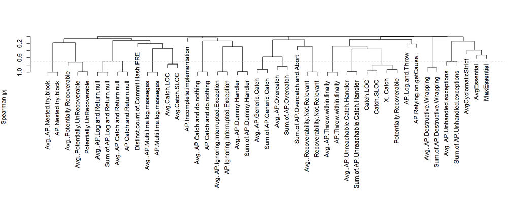

```
## [1] "NumberOfMetricsInitial: 49"
## [1] "NumberOfMetricsKept: 23"
## [1] "Distinct.count.of.Commit.Hash.PRE + AvgCyclomaticStrict + AvgEssential + MaxEssential + Avg.Catch.LOC + Avg..AP.Catch.and.do.nothing + Avg..AP.Catch.and.Return.null + Avg..AP.Destructive.Wrapping + Avg..AP.Dummy.Handler + Avg..AP.Generic.Catch + Avg..AP.Ignoring.Interrupted.Exception + Avg..…
##  [1] "Distinct.count.of.Commit.Hash.PRE"      "Distinct.count.of.Issue.Key.POST"
##  [3] "AvgCyclomaticStrict"                    "AvgEssential"
##  [5] "MaxEssential"                           "Avg.Catch.LOC"
##  [7] "Avg..AP.Catch.and.do.nothing"           "Avg..AP.Catch.and.Return.null"
##  [9] "Avg..AP.Destructive.Wrapping"           "Avg..AP.Dummy.Handler"
## [11] "Avg..AP.Generic.Catch"                  "Avg..AP.Ignoring.Interrupted.Exception"
## [13] "Avg..AP.Multi.line.log.messages"        "Avg..AP.Nested.try.block"
## [15] "Avg..AP.Throw.within.finally"           "Avg..AP.Unhandled.exceptions"
## [17] "Avg..AP.Unreachable.Catch.Handler"      "Avg..Potentially.UnRecoverable"
## [19] "Avg..Recoverability.Not.Relevant"       "AP.Incomplete.implementation"
## [21] "AP.Log.and.Throw"                       "Sum.of.AP.Overcatch.and.Abort"
## [23] "AP.Relying.on.getCause.."               "Potentially.Recoverable"
## [1] "Project: hibernate-5.0 Name: CAT.BASE"
```

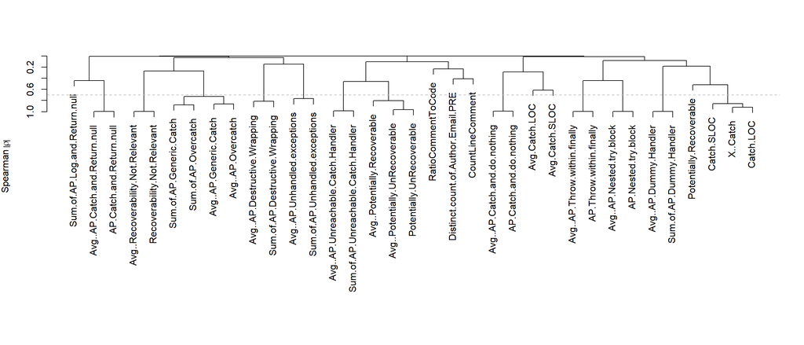

```
## [1] "NumberOfMetricsInitial: 48"
## [1] "NumberOfMetricsKept: 19"
## [1] "Distinct.count.of.Author.Email.PRE + CountLineComment + RatioCommentToCode + Avg.Catch.LOC + Avg.Catch.SLOC + Avg..AP.Catch.and.do.nothing + Avg..AP.Catch.and.Return.null + Avg..AP.Generic.Catch + Avg..AP.Nested.try.block + Avg..AP.Throw.within.finally + Avg..AP.Unhandled.exceptions + Avg..A…
##  [1] "Distinct.count.of.Author.Email.PRE" "Distinct.count.of.Issue.Key.POST"
##  [3] "CountLineComment"                   "RatioCommentToCode"
##  [5] "Avg.Catch.LOC"                      "Avg.Catch.SLOC"
##  [7] "Avg..AP.Catch.and.do.nothing"       "Avg..AP.Catch.and.Return.null"
##  [9] "Avg..AP.Generic.Catch"              "Avg..AP.Nested.try.block"
## [11] "Avg..AP.Throw.within.finally"       "Avg..AP.Unhandled.exceptions"
## [13] "Avg..AP.Unreachable.Catch.Handler"  "Avg..Potentially.Recoverable"
## [15] "Avg..Recoverability.Not.Relevant"   "Sum.of.AP.Destructive.Wrapping"
## [17] "Sum.of.AP.Dummy.Handler"            "Sum.of.AP.Log.and.Return.null"
## [19] "Catch.SLOC"                         "Potentially.Recoverable"
## [1] "Project: umbraco-7.6 Name: CAT.BASE"
```

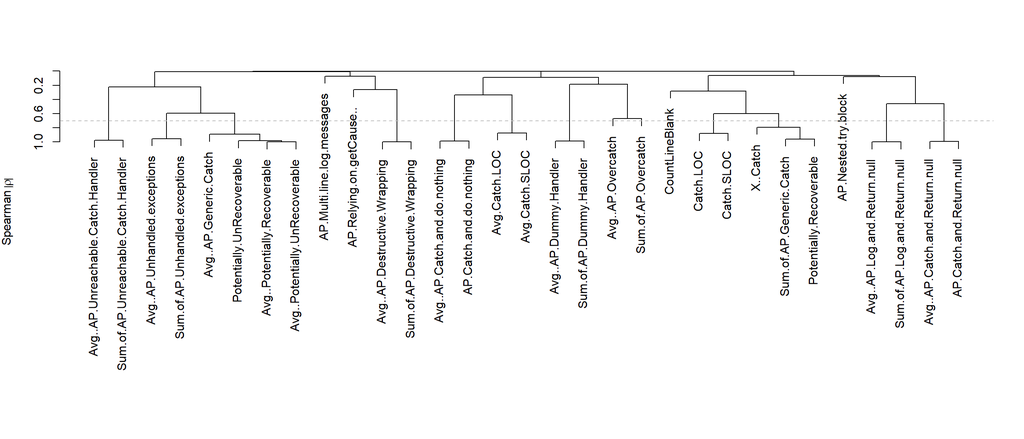

```
## [1] "NumberOfMetricsInitial: 46"
## [1] "NumberOfMetricsKept: 16"
## [1] "CountLineBlank + Avg.Catch.LOC + Avg..AP.Catch.and.Return.null + Avg..AP.Destructive.Wrapping + Avg..AP.Dummy.Handler + Avg..AP.Log.and.Return.null + Avg..AP.Overcatch + Avg..AP.Unhandled.exceptions + Avg..AP.Unreachable.Catch.Handler + Avg..Potentially.UnRecoverable + AP.Catch.and.do.nothin…
##  [1] "Distinct.count.of.Issue.Key.POST"  "CountLineBlank"                    "Avg.Catch.LOC"
##  [4] "Avg..AP.Catch.and.Return.null"     "Avg..AP.Destructive.Wrapping"      "Avg..AP.Dummy.Handler"
##  [7] "Avg..AP.Log.and.Return.null"       "Avg..AP.Overcatch"                 "Avg..AP.Unhandled.exceptions"
## [10] "Avg..AP.Unreachable.Catch.Handler" "Avg..Potentially.UnRecoverable"    "AP.Catch.and.do.nothing"
## [13] "Sum.of.AP.Generic.Catch"           "AP.Multi.line.log.messages"        "AP.Nested.try.block"
## [16] "Sum.of.AP.Overcatch"               "AP.Relying.on.getCause.."
## [1] "Project: hadoop-2.6 Name: CAT.BASE"
## [1] "Redudant variables: "
## [1] "Final variables: Distinct.count.of.Commit.Hash.PRE + Distinct.count.of.Issue.Key.POST + AvgCyclomaticStrict + AvgEssential + MaxEssential + Avg.Catch.LOC + Avg..AP.Catch.and.do.nothing + Avg..AP.Catch.and.Return.null + Avg..AP.Destructive.Wrapping + Avg..AP.Dummy.Handler + Avg..AP.Generic.Ca…
## [1] "NumberOfMetricsInitial: 24"
## [1] "NumberOfMetricsKept: 24"
## [1] "Project: hibernate-5.0 Name: CAT.BASE"
```

[output cut: 16 more lines]

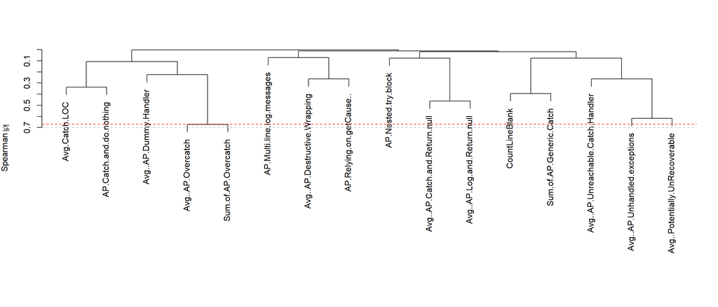

```
## [1] "CountLineBlank + Avg.Catch.LOC + Avg..AP.Catch.and.Return.null + Avg..AP.Destructive.Wrapping + Avg..AP.Dummy.Handler + Avg..AP.Log.and.Return.null + Avg..AP.Overcatch + Avg..AP.Unhandled.exceptions + Avg..AP.Unreachable.Catch.Handler + Avg..Potentially.UnRecoverable + AP.Catch.and.do.nothin…
## [1] "NumberOfMetricsInitial: 16 Budget: 15 Over Budget: TRUE NumberOfMetricsKept: 15 CorrelationCutoff: 0.671"
## [1] "NumberOfMetricsInitial: 16 Budget: 15 Over Budget: TRUE NumberOfMetricsKept: 15 CorrelationCutoff: 0.671"
```

#### Setup formulas

```r
form_list_bin_m2 = dataSetupFormulasBinaryByModel(all_list_model_m2)
```

```
## [1] "Project: hadoop-2.6 Name: CAT.BASE"
## [1] "Distinct.count.of.Commit.Hash.PRE + AvgCyclomaticStrict + AvgEssential + MaxEssential + Avg.Catch.LOC + Avg..AP.Catch.and.do.nothing + Avg..AP.Catch.and.Return.null + Avg..AP.Destructive.Wrapping + Avg..AP.Dummy.Handler + Avg..AP.Generic.Catch + Avg..AP.Ignoring.Interrupted.Exception + Avg..…
## [1] "Project: hibernate-5.0 Name: CAT.BASE"
## [1] "Distinct.count.of.Author.Email.PRE + CountLineComment + RatioCommentToCode + Avg.Catch.LOC + Avg.Catch.SLOC + Avg..AP.Catch.and.do.nothing + Avg..AP.Catch.and.Return.null + Avg..AP.Generic.Catch + Avg..AP.Nested.try.block + Avg..AP.Throw.within.finally + Avg..AP.Unhandled.exceptions + Avg..A…
## [1] "Project: umbraco-7.6 Name: CAT.BASE"
## [1] "CountLineBlank + Avg.Catch.LOC + Avg..AP.Catch.and.Return.null + Avg..AP.Destructive.Wrapping + Avg..AP.Dummy.Handler + Avg..AP.Log.and.Return.null + Avg..AP.Overcatch + Avg..AP.Unhandled.exceptions + Avg..AP.Unreachable.Catch.Handler + Avg..Potentially.UnRecoverable + AP.Catch.and.do.nothin…
```

#### Fit regression model (MC7)

```r
models_2_BSAP = modelFitLogisticByModel(all_list_model_m2,form_list_bin_m2,"CAT.BSAP")
```

```
## [1] "Project: hadoop-2.6 Name: CAT.BASE"
## Logistic Regression Model
##
## lrm(formula = as.formula(form_bin), data = temp_data_log, x = T,
##     y = T)
##
##                        Model Likelihood       Discrimination    Rank Discrim.
##                              Ratio Test              Indexes          Indexes
## Obs           890    LR chi2     233.46       R2       0.394    C       0.862
##  FALSE        747    d.f.            23      R2(23,890)0.211    Dxy     0.724
##  TRUE         143    Pr(> chi2) <0.0001    R2(23,360.1)0.443    gamma   0.724
## max |deriv| 2e-06                             Brier    0.095    tau-a   0.196
##
##                                        Coef    S.E.   Wald Z Pr(>|Z|)
## Intercept                              -4.8011 1.0842 -4.43  <0.0001
## Distinct.count.of.Commit.Hash.PRE       2.9187 0.3478  8.39  <0.0001
## AvgCyclomaticStrict                     2.9866 1.0155  2.94  0.0033
## AvgEssential                           -3.9923 1.6472 -2.42  0.0154
## MaxEssential                            0.6824 0.5346  1.28  0.2018
## Avg.Catch.LOC                           1.3236 1.1710  1.13  0.2584
## Avg..AP.Catch.and.do.nothing            0.5908 2.2376  0.26  0.7917
## Avg..AP.Catch.and.Return.null          -2.4554 2.1356 -1.15  0.2502
## Avg..AP.Destructive.Wrapping           -0.9398 1.1800 -0.80  0.4258
## Avg..AP.Dummy.Handler                   0.9190 1.4537  0.63  0.5273
## Avg..AP.Generic.Catch                  -1.9456 1.4520 -1.34  0.1803
## Avg..AP.Ignoring.Interrupted.Exception  5.1785 1.5936  3.25  0.0012
## Avg..AP.Multi.line.log.messages         0.8636 3.0204  0.29  0.7749
## Avg..AP.Nested.try.block                2.0894 2.3797  0.88  0.3799
## Avg..AP.Throw.within.finally           -3.5422 2.3058 -1.54  0.1245
## Avg..AP.Unhandled.exceptions           -1.1283 1.1293 -1.00  0.3177
## Avg..AP.Unreachable.Catch.Handler       0.2953 1.9069  0.15  0.8769
## Avg..Potentially.UnRecoverable          0.5821 1.8214  0.32  0.7493
## Avg..Recoverability.Not.Relevant       -4.4751 3.2719 -1.37  0.1714
## AP.Incomplete.implementation            2.6999 4.1987  0.64  0.5202
## AP.Log.and.Throw                        4.1366 2.0714  2.00  0.0458
## Sum.of.AP.Overcatch.and.Abort           0.1437 2.1522  0.07  0.9468
## AP.Relying.on.getCause..               -0.6957 1.3245 -0.53  0.5994
## Potentially.Recoverable                 0.8492 0.3661  2.32  0.0204
##
## [1] "Project: hibernate-5.0 Name: CAT.BASE"
```

[output cut: 49 more lines]

```
## CountLineBlank                       1.3541    0.7092  1.91  0.0562
## Avg.Catch.LOC                       -2.0201    2.4530 -0.82  0.4102
## Avg..AP.Catch.and.Return.null        1.4990    3.9959  0.38  0.7076
## Avg..AP.Destructive.Wrapping      -152.9003 4260.8998 -0.04  0.9714
## Avg..AP.Dummy.Handler                6.3450    2.5708  2.47  0.0136
## Avg..AP.Log.and.Return.null        -16.9573   19.2148 -0.88  0.3775
## Avg..AP.Overcatch                   -1.0034    2.9496 -0.34  0.7337
## Avg..AP.Unhandled.exceptions       -11.7078    6.3338 -1.85  0.0645
## Avg..AP.Unreachable.Catch.Handler   -7.8174    4.3970 -1.78  0.0754
## Avg..Potentially.UnRecoverable      10.1290    6.9469  1.46  0.1448
## AP.Catch.and.do.nothing             -0.4214    1.9188 -0.22  0.8262
## Sum.of.AP.Generic.Catch              5.7515    1.8440  3.12  0.0018
## AP.Multi.line.log.messages         -46.6615 3451.1988 -0.01  0.9892
## AP.Nested.try.block                  0.1366    3.6782  0.04  0.9704
## AP.Relying.on.getCause..           -35.0581 2854.4729 -0.01  0.9902
```

#### Model Analysis for BSAP

In this section, we present the selected statistics for our analysis. As explained in our approach, they are the steps: MC7, MA1, MA2, MA3 and MA4.

Here we extract the selected statistics and we add the data (columns) to an object that will be exported to CSV in the section Output.

##### Fit regression model (MC7): summary stats

```r
model_things_2_BSAP = vector("list", 0)
model_things_2_BSAP = modelStats(models_2_BSAP)
```

##### Model stability assessment (MA1)

```r
model_things_2_BSAP = modelValidate(models_2_BSAP, model_things_2_BSAP)
```

[output not shown]

[output cut: 68 more lines]

[output not shown]

##### Model significant variables

```r
model_things_2_BSAP = modelSignificance(models_2_BSAP, model_things_2_BSAP)
```

```
## [1] "project:  hadoop-2.6 model:  CAT.BSAP"
##                 Wald Statistics          Response: Distinct.count.of.Issue.Key.POST > 0
##
##  Factor                                 Chi-Square d.f. P
##  Distinct.count.of.Commit.Hash.PRE       70.44      1   <.0001
##  AvgCyclomaticStrict                      8.65      1   0.0033
##  AvgEssential                             5.87      1   0.0154
##  MaxEssential                             1.63      1   0.2018
##  Avg.Catch.LOC                            1.28      1   0.2584
##  Avg..AP.Catch.and.do.nothing             0.07      1   0.7917
##  Avg..AP.Catch.and.Return.null            1.32      1   0.2502
##  Avg..AP.Destructive.Wrapping             0.63      1   0.4258
##  Avg..AP.Dummy.Handler                    0.40      1   0.5273
##  Avg..AP.Generic.Catch                    1.80      1   0.1803
##  Avg..AP.Ignoring.Interrupted.Exception  10.56      1   0.0012
##  Avg..AP.Multi.line.log.messages          0.08      1   0.7749
##  Avg..AP.Nested.try.block                 0.77      1   0.3799
##  Avg..AP.Throw.within.finally             2.36      1   0.1245
##  Avg..AP.Unhandled.exceptions             1.00      1   0.3177
##  Avg..AP.Unreachable.Catch.Handler        0.02      1   0.8769
##  Avg..Potentially.UnRecoverable           0.10      1   0.7493
##  Avg..Recoverability.Not.Relevant         1.87      1   0.1714
##  AP.Incomplete.implementation             0.41      1   0.5202
##  AP.Log.and.Throw                         3.99      1   0.0458
##  Sum.of.AP.Overcatch.and.Abort            0.00      1   0.9468
##  AP.Relying.on.getCause..                 0.28      1   0.5994
##  Potentially.Recoverable                  5.38      1   0.0204
##  TOTAL                                  149.23     23   <.0001
## [1] "project:  hibernate-5.0 model:  CAT.BSAP"
##                 Wald Statistics          Response: Distinct.count.of.Issue.Key.POST > 0
##
##  Factor                             Chi-Square d.f. P
##  Distinct.count.of.Author.Email.PRE  8.97       1   0.0028
##  CountLineComment                   12.44       1   0.0004
##  RatioCommentToCode                 10.57       1   0.0011
##  Avg.Catch.LOC                       0.40       1   0.5257
##  Avg.Catch.SLOC                      3.95       1   0.0467
##  Avg..AP.Catch.and.do.nothing        0.11       1   0.7353
##  Avg..AP.Catch.and.Return.null       3.01       1   0.0825
##  Avg..AP.Generic.Catch               0.19       1   0.6626
```

[output cut: 17 more lines]

```
##  Avg.Catch.LOC                      0.68       1   0.4102
##  Avg..AP.Catch.and.Return.null      0.14       1   0.7076
##  Avg..AP.Destructive.Wrapping       0.00       1   0.9714
##  Avg..AP.Dummy.Handler              6.09       1   0.0136
##  Avg..AP.Log.and.Return.null        0.78       1   0.3775
##  Avg..AP.Overcatch                  0.12       1   0.7337
##  Avg..AP.Unhandled.exceptions       3.42       1   0.0645
##  Avg..AP.Unreachable.Catch.Handler  3.16       1   0.0754
##  Avg..Potentially.UnRecoverable     2.13       1   0.1448
##  AP.Catch.and.do.nothing            0.05       1   0.8262
##  Sum.of.AP.Generic.Catch            9.73       1   0.0018
##  AP.Multi.line.log.messages         0.00       1   0.9892
##  AP.Nested.try.block                0.00       1   0.9704
##  AP.Relying.on.getCause..           0.00       1   0.9902
##  TOTAL                             21.92      15   0.1099
```

##### Model simplification (MA2), Predictors’ explanatory power estimation (MA3), Predictors’ effect in the outcome measurement (MA4)

```r
model_things_2_BSAP = modelSimplification(models_2_BSAP, model_things_2_BSAP)
```

```
## [1] "project:  hadoop-2.6 model:  CAT.BSAP Refit"
## Logistic Regression Model
##
## lrm(formula = as.formula(final_form), data = temp_data, x = T,
##     y = T)
##
##                        Model Likelihood      Discrimination    Rank Discrim.
##                              Ratio Test             Indexes          Indexes
## Obs           890    LR chi2     215.21      R2       0.367    C       0.848
##  FALSE        747    d.f.             6      R2(6,890)0.209    Dxy     0.696
##  TRUE         143    Pr(> chi2) <0.0001    R2(6,360.1)0.441    gamma   0.698
## max |deriv| 3e-09                            Brier    0.098    tau-a   0.188
##
##                                        Coef    S.E.   Wald Z Pr(>|Z|)
## Intercept                              -4.2845 0.5392 -7.95  <0.0001
## Distinct.count.of.Commit.Hash.PRE       3.2525 0.3124 10.41  <0.0001
## AvgCyclomaticStrict                     3.1582 0.9624  3.28  0.0010
## AvgEssential                           -2.9884 1.3791 -2.17  0.0302
## Avg..AP.Ignoring.Interrupted.Exception  5.1063 1.4278  3.58  0.0003
## AP.Log.and.Throw                        4.1034 1.9466  2.11  0.0350
## Potentially.Recoverable                 0.7444 0.2817  2.64  0.0082
##
## [1] "project:  hadoop-2.6 model:  CAT.BSAP Refit - summary"
## [1] "project:  hadoop-2.6 model:  CAT.BSAP Refit - validate"
## [1] "project:  hadoop-2.6 model:  CAT.BSAP Refit - anova"
##                 Wald Statistics          Response: Distinct.count.of.Issue.Key.POST > 0
##
##  Factor                                 Chi-Square d.f. P
##  Distinct.count.of.Commit.Hash.PRE      108.40     1    <.0001
##  AvgCyclomaticStrict                     10.77     1    0.0010
##  AvgEssential                             4.70     1    0.0302
##  Avg..AP.Ignoring.Interrupted.Exception  12.79     1    0.0003
##  AP.Log.and.Throw                         4.44     1    0.0350
##  Potentially.Recoverable                  6.98     1    0.0082
##  TOTAL                                  147.46     6    <.0001
## [1] "Distinct.count.of.Commit.Hash.PRE"
## [1] "AvgCyclomaticStrict"
## [1] "AvgEssential"
## [1] "Avg..AP.Ignoring.Interrupted.Exception"
## [1] "AP.Log.and.Throw"
```

[output cut: 77 more lines]

```
## [1] "project:  umbraco-7.6 model:  CAT.BSAP Refit - validate"
## [1] "project:  umbraco-7.6 model:  CAT.BSAP Refit - anova"
##                 Wald Statistics          Response: Distinct.count.of.Issue.Key.POST > 0
##
##  Factor                  Chi-Square d.f. P
##  Avg..AP.Dummy.Handler    7.58      1    0.0059
##  Sum.of.AP.Generic.Catch 14.82      1    0.0001
##  TOTAL                   18.68      2    0.0001
## [1] "Avg..AP.Dummy.Handler"
## [1] "Sum.of.AP.Generic.Catch"
##   Avg..AP.Dummy.Handler Sum.of.AP.Generic.Catch
## 1              0.160471                1.852174
## [1] "Fixed at Mean: 0.0850053202474648"
## [1] "Avg..AP.Dummy.Handler  Coef at Mean + 10%: 0.0875005781572317"
## [1] "Sum.of.AP.Generic.Catch  Coef at Mean + 10%: 0.0939165463703944"
```

### Model Extension: BASE + EH Try

```r
all_list_omitted_m3 = all_list_omitted
```

#### Drop variables - adjust metric sets

To be able to build new models that are an extension of the base model we removed all insignificant metrics according to the related base model construction. This process makes sense since one can adjust metrics based on expertise. In this case, we learned in the previous step what are the significant metrics for base only, therefore we can remove the other base metrics. In this process we need to loop through each model previously built. Each model can have a different set of metrics and, therefore, the construction of their extensions have to be separately done.

```r
all_list_omitted_m3 = vector("list", 0)

for (i in 1:length(models_2_BASE)) {
  name = models_2_BASE[[i]]$name
  project = models_2_BASE[[i]]$project
  fit = models_2_BASE[[i]]$fit
  class = as.character(class(fit)[1])
  print(paste("Project:", project, "Name:", name))

  if(class != "try-error") {

    temp_data_index = findProjectData(all_list_omitted,project)
    temp_data = as.data.frame(all_list_omitted[[temp_data_index]]$data)

    # Keep catch metrics, remove try and throws, adjust base.
    keepForID = c("Project", "File.Path")
    keepForBase = c("Distinct.count.of.Issue.Key.POST",keepForID)
    keepForCatch = c(keepForID)
    keepForThrows = c(keepForID)

    base_names_drop = base_names[!(base_names %in% keepForBase)]
    catch_names_drop = catch_names[!(catch_names %in% keepForCatch)]
    throws_names_drop = throws_names[!(throws_names %in% keepForThrows)]

    temp_data = temp_data[,!(names(temp_data) %in% catch_names_drop)]
    temp_data = temp_data[,!(names(temp_data) %in% throws_names_drop)]

    # Remove insignificant metrics according to related base model.
    temp_sig_index = findModel(model_things_2_BASE,name,project)

    # Only move forward with the models that are under budget.
    if (!model_things_2_BASE[[temp_sig_index]][["over_budget"]]){
      temp_significant = model_things_2_BASE[[temp_sig_index]][["signifcant_r"]]
      if (!is.na(temp_significant)) {
        # The significant metrics from the base model as a vector of char.
        temp_significant_list = unlist(strsplit(temp_significant, ", "))
      } else
        temp_significant_list = unlist(strsplit("", ", "))

      # The insignificant metrics: all from the base model minus the significant ones.
      base_names_insignificant = base_names_drop[!(base_names_drop %in% temp_significant_list)]
      # The clean list of metrics for modeling: all metrics minus the base insignificant ones.
      temp_data = temp_data[,!(names(temp_data) %in% base_names_insignificant)]
      print(names(temp_data))

      all_list_omitted_m3 <- c(all_list_omitted_m3, list(list(name=name, project=project, data=temp_data, sig=temp_significant_list)))
    } else
      print(paste("!-ERROR-! - model over budget."))

  } else
    print(paste("!-ERROR-! - model construction had issues."))
}
```

```
## [1] "Project: hadoop-2.6 Name: CAT.BASE"
##  [1] "Distinct.count.of.Commit.Hash.PRE"           "Distinct.count.of.Issue.Key.POST"
##  [3] "AvgCyclomaticStrict"                         "AvgEssential"
##  [5] "MaxEssential"                                "X..Try.in.Conditional"
##  [7] "X..Try.in.Declaration"                       "X..Try.in.EH.Feature"
##  [9] "X..Try.in.Loop"                              "X..Try.in.Other"
## [11] "X..Try"                                      "X..Try.in.Conditional.1"
## [13] "X..Try.in.Declaration.1"                     "X..Try.in.EH.Feature.1"
## [15] "X..Try.in.Loop.1"                            "X..Try.in.Other.1"
## [17] "Avg.Max.Depth"                               "Avg.Try.LOC"
## [19] "Avg.Try.SLOC"                                "X..Handled.with.Abort"
## [21] "X..Handled.with.Continue"                    "X..Handled.with.Default"
## [23] "X..Handled.with.Empty"                       "X..Handled.with.Log"
## [25] "X..Handled.with.Method"                      "X..Handled.with.Nested.Try"
## [27] "X..Handled.with.Return"                      "X..Handled.with.Throw.with.New"
```

[output cut: 80 more lines]

```r
dropToPredict = c("File.Path",  "Project", "Language", "Table.Name","Name","Kind", "X..Bugs.Post", "File", "Distinct.count.of.Issue.Key.POST")
```

#### Correlation analysis (MC4), Redundancy Analysis (MC5), Budget based correlation analysis (MC6)

```r
all_list_model_m3 = dataApplyReductionByModel(all_list_omitted_m3, "BSFC")
```

```
## [1] "Project: hadoop-2.6 Name: CAT.BASE"
```

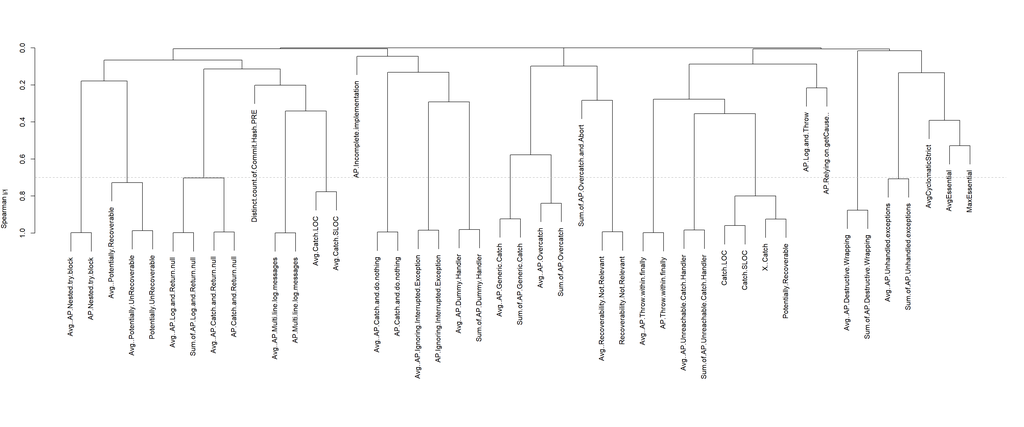

[output not shown]

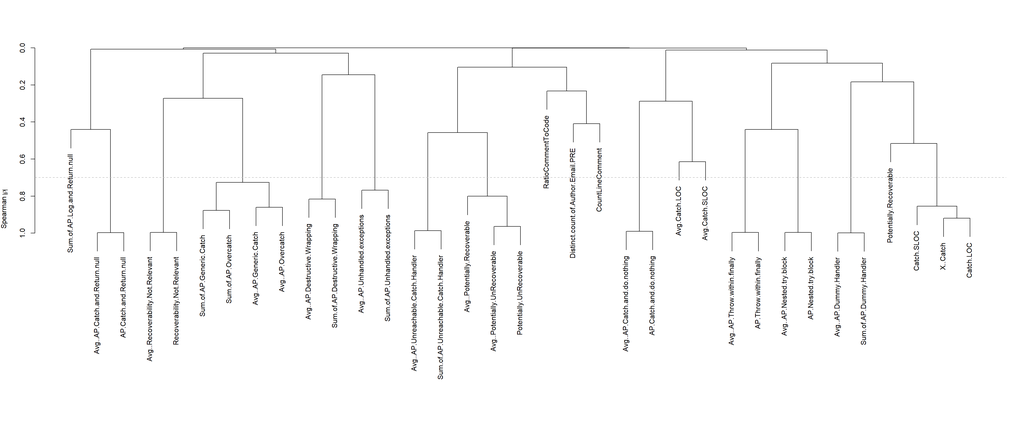

[output not shown]

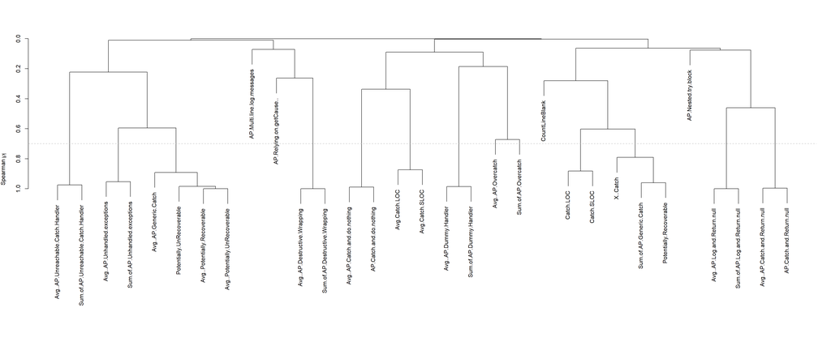

[output not shown]

[output cut: 16 more lines]

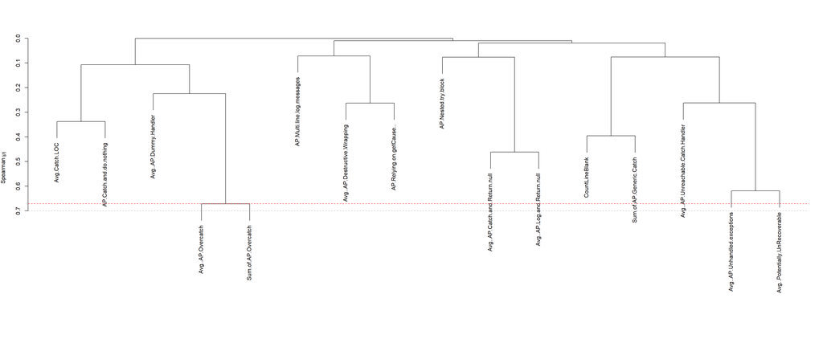

```
## [1] "CountLineBlank + Avg.Catch.LOC + Avg..AP.Catch.and.Return.null + Avg..AP.Destructive.Wrapping + Avg..AP.Dummy.Handler + Avg..AP.Log.and.Return.null + Avg..AP.Overcatch + Avg..AP.Unhandled.exceptions + Avg..AP.Unreachable.Catch.Handler + Avg..Potentially.UnRecoverable + AP.Catch.and.do.nothin…
## [1] "NumberOfMetricsInitial: 16 Budget: 15 Over Budget: TRUE NumberOfMetricsKept: 15 CorrelationCutoff: 0.671"
## [1] "NumberOfMetricsInitial: 16 Budget: 15 Over Budget: TRUE NumberOfMetricsKept: 15 CorrelationCutoff: 0.671"
```

#### Setup formulas

```r
form_list_bin_m3 = dataSetupFormulasBinaryByModel(all_list_model_m3)
```

```
## [1] "Project: hadoop-2.6 Name: CAT.BASE"
## [1] "Distinct.count.of.Commit.Hash.PRE + AvgCyclomaticStrict + AvgEssential + MaxEssential + Avg.Catch.LOC + Avg..AP.Catch.and.do.nothing + Avg..AP.Catch.and.Return.null + Avg..AP.Destructive.Wrapping + Avg..AP.Dummy.Handler + Avg..AP.Generic.Catch + Avg..AP.Ignoring.Interrupted.Exception + Avg..…
## [1] "Project: hibernate-5.0 Name: CAT.BASE"
## [1] "Distinct.count.of.Author.Email.PRE + CountLineComment + RatioCommentToCode + Avg.Catch.LOC + Avg.Catch.SLOC + Avg..AP.Catch.and.do.nothing + Avg..AP.Catch.and.Return.null + Avg..AP.Generic.Catch + Avg..AP.Nested.try.block + Avg..AP.Throw.within.finally + Avg..AP.Unhandled.exceptions + Avg..A…
## [1] "Project: umbraco-7.6 Name: CAT.BASE"
## [1] "CountLineBlank + Avg.Catch.LOC + Avg..AP.Catch.and.Return.null + Avg..AP.Destructive.Wrapping + Avg..AP.Dummy.Handler + Avg..AP.Log.and.Return.null + Avg..AP.Overcatch + Avg..AP.Unhandled.exceptions + Avg..AP.Unreachable.Catch.Handler + Avg..Potentially.UnRecoverable + AP.Catch.and.do.nothin…
```

#### Fit regression model (MC7)

```r
models_2_BSFC = modelFitLogisticByModel(all_list_model_m3,form_list_bin_m3,"CAT.BSFC")
```

[output not shown]

[output cut: 49 more lines]

```
## CountLineBlank                       1.3541    0.7092  1.91  0.0562
## Avg.Catch.LOC                       -2.0201    2.4530 -0.82  0.4102
## Avg..AP.Catch.and.Return.null        1.4990    3.9959  0.38  0.7076
## Avg..AP.Destructive.Wrapping      -152.9003 4260.8998 -0.04  0.9714
## Avg..AP.Dummy.Handler                6.3450    2.5708  2.47  0.0136
## Avg..AP.Log.and.Return.null        -16.9573   19.2148 -0.88  0.3775
## Avg..AP.Overcatch                   -1.0034    2.9496 -0.34  0.7337
## Avg..AP.Unhandled.exceptions       -11.7078    6.3338 -1.85  0.0645
## Avg..AP.Unreachable.Catch.Handler   -7.8174    4.3970 -1.78  0.0754
## Avg..Potentially.UnRecoverable      10.1290    6.9469  1.46  0.1448
## AP.Catch.and.do.nothing             -0.4214    1.9188 -0.22  0.8262
## Sum.of.AP.Generic.Catch              5.7515    1.8440  3.12  0.0018
## AP.Multi.line.log.messages         -46.6615 3451.1988 -0.01  0.9892
## AP.Nested.try.block                  0.1366    3.6782  0.04  0.9704
## AP.Relying.on.getCause..           -35.0581 2854.4729 -0.01  0.9902
```

#### Model Analysis for BSFC

In this section, we present the selected statistics for our analysis. As explained in our approach, they are the steps: MC7, MA1, MA2, MA3 and MA4.

Here we extract the selected statistics and we add the data (columns) to an object that will be exported to CSV in the section Output.

##### Fit regression model (MC7): summary stats

```r
model_things_2_BSFC = vector("list", 0)
model_things_2_BSFC = modelStats(models_2_BSFC)
```

##### Model stability assessment (MA1)

```r
model_things_2_BSFC = modelValidate(models_2_BSFC, model_things_2_BSFC)
```

[output not shown]

[output cut: 161 more lines]

[output not shown]

##### Model significant variables

```r
model_things_2_BSFC = modelSignificance(models_2_BSFC, model_things_2_BSFC)
```

```
## [1] "project:  hadoop-2.6 model:  CAT.BSFC"
##                 Wald Statistics          Response: Distinct.count.of.Issue.Key.POST > 0
##
##  Factor                                 Chi-Square d.f. P
##  Distinct.count.of.Commit.Hash.PRE       70.44      1   <.0001
##  AvgCyclomaticStrict                      8.65      1   0.0033
##  AvgEssential                             5.87      1   0.0154
##  MaxEssential                             1.63      1   0.2018
##  Avg.Catch.LOC                            1.28      1   0.2584
##  Avg..AP.Catch.and.do.nothing             0.07      1   0.7917
##  Avg..AP.Catch.and.Return.null            1.32      1   0.2502
##  Avg..AP.Destructive.Wrapping             0.63      1   0.4258
##  Avg..AP.Dummy.Handler                    0.40      1   0.5273
##  Avg..AP.Generic.Catch                    1.80      1   0.1803
##  Avg..AP.Ignoring.Interrupted.Exception  10.56      1   0.0012
##  Avg..AP.Multi.line.log.messages          0.08      1   0.7749
##  Avg..AP.Nested.try.block                 0.77      1   0.3799
##  Avg..AP.Throw.within.finally             2.36      1   0.1245
##  Avg..AP.Unhandled.exceptions             1.00      1   0.3177
##  Avg..AP.Unreachable.Catch.Handler        0.02      1   0.8769
##  Avg..Potentially.UnRecoverable           0.10      1   0.7493
##  Avg..Recoverability.Not.Relevant         1.87      1   0.1714
##  AP.Incomplete.implementation             0.41      1   0.5202
##  AP.Log.and.Throw                         3.99      1   0.0458
##  Sum.of.AP.Overcatch.and.Abort            0.00      1   0.9468
##  AP.Relying.on.getCause..                 0.28      1   0.5994
##  Potentially.Recoverable                  5.38      1   0.0204
##  TOTAL                                  149.23     23   <.0001
## [1] "project:  hibernate-5.0 model:  CAT.BSFC"
##                 Wald Statistics          Response: Distinct.count.of.Issue.Key.POST > 0
##
##  Factor                             Chi-Square d.f. P
##  Distinct.count.of.Author.Email.PRE  8.97       1   0.0028
##  CountLineComment                   12.44       1   0.0004
##  RatioCommentToCode                 10.57       1   0.0011
##  Avg.Catch.LOC                       0.40       1   0.5257
##  Avg.Catch.SLOC                      3.95       1   0.0467
##  Avg..AP.Catch.and.do.nothing        0.11       1   0.7353
##  Avg..AP.Catch.and.Return.null       3.01       1   0.0825
##  Avg..AP.Generic.Catch               0.19       1   0.6626
```

[output cut: 17 more lines]

```
##  Avg.Catch.LOC                      0.68       1   0.4102
##  Avg..AP.Catch.and.Return.null      0.14       1   0.7076
##  Avg..AP.Destructive.Wrapping       0.00       1   0.9714
##  Avg..AP.Dummy.Handler              6.09       1   0.0136
##  Avg..AP.Log.and.Return.null        0.78       1   0.3775
##  Avg..AP.Overcatch                  0.12       1   0.7337
##  Avg..AP.Unhandled.exceptions       3.42       1   0.0645
##  Avg..AP.Unreachable.Catch.Handler  3.16       1   0.0754
##  Avg..Potentially.UnRecoverable     2.13       1   0.1448
##  AP.Catch.and.do.nothing            0.05       1   0.8262
##  Sum.of.AP.Generic.Catch            9.73       1   0.0018
##  AP.Multi.line.log.messages         0.00       1   0.9892
##  AP.Nested.try.block                0.00       1   0.9704
##  AP.Relying.on.getCause..           0.00       1   0.9902
##  TOTAL                             21.92      15   0.1099
```

##### Model simplification (MA2), Predictors’ explanatory power estimation (MA3), Predictors’ effect in the outcome measurement (MA4)

```r
model_things_2_BSFC = modelSimplification(models_2_BSFC, model_things_2_BSFC)
```

```
## [1] "project:  hadoop-2.6 model:  CAT.BSFC Refit"
## Logistic Regression Model
##
## lrm(formula = as.formula(final_form), data = temp_data, x = T,
##     y = T)
##
##                        Model Likelihood      Discrimination    Rank Discrim.
##                              Ratio Test             Indexes          Indexes
## Obs           890    LR chi2     215.21      R2       0.367    C       0.848
##  FALSE        747    d.f.             6      R2(6,890)0.209    Dxy     0.696
##  TRUE         143    Pr(> chi2) <0.0001    R2(6,360.1)0.441    gamma   0.698
## max |deriv| 3e-09                            Brier    0.098    tau-a   0.188
##
##                                        Coef    S.E.   Wald Z Pr(>|Z|)
## Intercept                              -4.2845 0.5392 -7.95  <0.0001
## Distinct.count.of.Commit.Hash.PRE       3.2525 0.3124 10.41  <0.0001
## AvgCyclomaticStrict                     3.1582 0.9624  3.28  0.0010
## AvgEssential                           -2.9884 1.3791 -2.17  0.0302
## Avg..AP.Ignoring.Interrupted.Exception  5.1063 1.4278  3.58  0.0003
## AP.Log.and.Throw                        4.1034 1.9466  2.11  0.0350
## Potentially.Recoverable                 0.7444 0.2817  2.64  0.0082
##
## [1] "project:  hadoop-2.6 model:  CAT.BSFC Refit - summary"
## [1] "project:  hadoop-2.6 model:  CAT.BSFC Refit - validate"
## [1] "project:  hadoop-2.6 model:  CAT.BSFC Refit - anova"
##                 Wald Statistics          Response: Distinct.count.of.Issue.Key.POST > 0
##
##  Factor                                 Chi-Square d.f. P
##  Distinct.count.of.Commit.Hash.PRE      108.40     1    <.0001
##  AvgCyclomaticStrict                     10.77     1    0.0010
##  AvgEssential                             4.70     1    0.0302
##  Avg..AP.Ignoring.Interrupted.Exception  12.79     1    0.0003
##  AP.Log.and.Throw                         4.44     1    0.0350
##  Potentially.Recoverable                  6.98     1    0.0082
##  TOTAL                                  147.46     6    <.0001
## [1] "Distinct.count.of.Commit.Hash.PRE"
## [1] "AvgCyclomaticStrict"
## [1] "AvgEssential"
## [1] "Avg..AP.Ignoring.Interrupted.Exception"
## [1] "AP.Log.and.Throw"
```

[output cut: 77 more lines]

```
## [1] "project:  umbraco-7.6 model:  CAT.BSFC Refit - validate"
## [1] "project:  umbraco-7.6 model:  CAT.BSFC Refit - anova"
##                 Wald Statistics          Response: Distinct.count.of.Issue.Key.POST > 0
##
##  Factor                  Chi-Square d.f. P
##  Avg..AP.Dummy.Handler    7.58      1    0.0059
##  Sum.of.AP.Generic.Catch 14.82      1    0.0001
##  TOTAL                   18.68      2    0.0001
## [1] "Avg..AP.Dummy.Handler"
## [1] "Sum.of.AP.Generic.Catch"
##   Avg..AP.Dummy.Handler Sum.of.AP.Generic.Catch
## 1              0.160471                1.852174
## [1] "Fixed at Mean: 0.0850053202474648"
## [1] "Avg..AP.Dummy.Handler  Coef at Mean + 10%: 0.0875005781572317"
## [1] "Sum.of.AP.Generic.Catch  Coef at Mean + 10%: 0.0939165463703944"
```

## Output 2

Here we output the selected statistics from the R functions results and we output in the CSV files in the folder “output”.

```r
write.table(data.frame(model_things_2_BASE[[1]])[0,], 'output/base_test_2.csv'  , append= F, sep=',', row.names = F, col.names = T )

lapply(model_things_2_BASE, function(x) write.table( data.frame(x), 'output/base_test_2.csv'  , append= T, sep=',', row.names = F, col.names = F ))
```

```r
lapply(model_things_2_BSAP, function(x) write.table( data.frame(x), 'output/base_test_2.csv'  , append= T, sep=',', row.names = F, col.names = F ))
```

```r
lapply(model_things_2_BSFC, function(x) write.table( data.frame(x), 'output/base_test_2.csv'  , append= T, sep=',', row.names = F, col.names = F ))
```